# POP77022: Programming Exercise 2

Daniel Murray

March 3rd, 2023

## Overview

The second homework assignment covers concepts and methods from Weeks 3 and 4 (Supervised and unsupervised text classification).

Please provide your answers as code and text in the RMarkdown file provided. When completed, first knit the file as an HTML file and then save the resulting HTML document in PDF format. Upload the PDF to Turnitin.

## Supervised text classification of Yelp reviews (50 points)

We begin by analyzing a sample from the Zhang, Zhao & LeCun (2015) dataset of Yelp reviews which have been coded for sentiment polarity. The authors of the dataset have created a `sentiment` variable where a value of 1 indicates a “negative” review (1 or 2 stars), and a 2 means a “positive” review (3 or 4 stars).

First, bring in the reviews dataset from the `data` directory.

```r
setwd(getwd())
data <- read.csv("./data/yelp_data_small.csv",
                 stringsAsFactors=FALSE,
                 encoding = "utf-8")

# Load required libraries
library(quanteda)
library(quanteda.textmodels)
library(quanteda.textstats)
library(caret)
library(stringi)
library(ggplot2)
library('MLmetrics')
library('doParallel')
library(textstem)
```

1. Create a `quanteda` corpus object from this matrix and inspect its attributes.
   - What is the overall probability of the “positive” class in the corpus? Are the classes balanced? (Hint: Use the `table()` function)

```r
# Convert dataframe to corpus
corp <- quanteda::corpus(data,
                         text_field = "text")

# Inspect corpus attributes
print(summary(corp,5))
```

```
## Corpus consisting of 10000 documents, showing 5 documents:
##
##   Text Types Tokens Sentences sentiment
##  text1   112    211         9       neg
##  text2     5      5         1       pos
##  text3   187    355        17       pos
##  text4    89    131        10       pos
##  text5    98    156         4       pos
```

```r
# Inspect sentiment frequencies of corpus
print(table(corp$sentiment))
```

```
##
##  neg  pos
## 5088 4912
```

```r
# Calculate probability of "positive" class
cat("\n","Probability of 'positive' class: ", round(length(corp[corp$sentiment == "pos"])/length(corp),2))
```

```
##
##  Probability of 'positive' class:  0.49
```

Answer: The classes are broadly balanced with a 49%/51% positive/negative split.

2. Create a document-feature matrix using this corpus. Process the text so as to increase predictive power of the features. Justify each of your processing decisions in the context of the supervised classification task.

```r
# Remove line breaks from corpus
corp <- gsub("\\\\n", "", corp)

# Inspect first five corpus documents
head(corp, 5)
```

```
## Corpus consisting of 5 documents and 1 docvar.
## text1 :
## "It's hard to not compare a place like Blimpie to Subway beca..."
##
## text2 :
## "Great family place and price"
##
## text3 :
## "Oh, Armadillo Grill...you are something special.The first ti..."
##
## text4 :
## "I came here twice for breakfast.  The first morning I had th..."
##
## text5 :
## "It was the start of a long vacation and we just needed a roo..."
```

```r
# Tokenise text, removing punctuation/symbols/URLs, etc. and retaining docvars
toks <- quanteda::tokens(corp,
                         include_docvars = TRUE,
                         remove_numbers = TRUE,
                         remove_punct = TRUE,
                         remove_symbols = TRUE,
                         remove_hyphens = TRUE,
                         remove_separators = TRUE,
                         remove_url = TRUE)
# Convert tokens to lowercase
toks <- tokens_tolower(toks)

# Create list of stopwords and remove these from tokens, retaining whitespaces in place of removed stopwords
stop_list <- stopwords("english")
toks <- tokens_remove(toks, stop_list, padding=TRUE)

# Identify trigram collocations
trigrams <- textstat_collocations(toks,
                                  method = "lambda",
                                  size = 3,
                                  min_count = 5,
                                  smoothing = 0.5)

# Create list of trigrams of interest (z-score > 3)
trigrams <- trigrams[trigrams$z > 3,]

# Identify bigram collocations
bigrams <- textstat_collocations(toks,
                                 method = "lambda",
                                 size = 2,
                                 min_count = 20,
                                 smoothing = 0.5)

# Create list of bigrams of interest (z-score > 30)
bigrams <- bigrams[bigrams$z > 30,]

# Compile a list of collocations to keep
keep_coll_list <- rbind(trigrams, bigrams)

# Merge collocations with tokens and remove whitespaces
toks_col <- tokens_compound(toks,
                            pattern = keep_coll_list)
toks_col <- tokens_remove(toks_col, "")

# Create dfm
dfm <- dfm(toks_col)

# Check term keyness by class group
dfm_keyness <- dfm_group(dfm, groups = sentiment)
keyness_stat <- textstat_keyness(dfm_keyness, target = "pos")

# Compile list of most predictive features
high_key_features <- keyness_stat[order(keyness_stat$p),]

# Compile list of features with low predictive power
low_key_features <- keyness_stat[keyness_stat$p > 0.05,]

# Remove features with low predictive power from dfm
dfm <- dfm_remove(dfm, pattern = low_key_features$feature)

# Weight dfm
dfm <- dfm_tfidf(dfm)
```

Answer:

In order to reduce dimensionality and noise and increase the predictive power of the resultant features, the following tasks were performed:

- Removal of line breaks
- Removal of punctuation/symbols/hyphens/URLs
- Lowercasing of tokens
- Removal of stopwords

Trigrams and bigrams were identified with respective minimum frequencies to reduce dimensionality. Collocations to keep were selected using a threshold of z > 3 (trigrams) and z > 30 (bigrams) as these values were both statistically robust and around the point where collocations appeared to stop exhibiting any potential predictive power warranting inclusion from a theoretical point of view.

After creation of the dfm, key features for each class were identified. Features with a p-value > 0.05 were removed as these were deemed to have little predictive power. This would further reduce dimensionality and noise, making the resulting model more efficient and effective.

Lemmatisation was not performed in order to retain docvars. Stemming and trimming were not performed in order to retain as many features with high predictive power as possible prior to calculation of keyness and subsequent feature removal (as outlined above).

3. Now that you have your document-feature matrix, use the `caret` library to create a training set and testing set following an 80/20 split.

```r
# Convert dfm to data frame for input into supervised ML pipeline
tmpdata <- convert(dfm, to = "data.frame", docvars = NULL)

# Drop doc_id variable
tmpdata <- tmpdata[, -1]

# Get sentiment labels
human_labels <- dfm@docvars$sentiment

# Join sentiment labels to data frame
tmpdata <- as.data.frame(cbind(human_labels, tmpdata))

## Create Train, Test and Validation Sets ##

# Set seed for replicability
set.seed(1234)

# Randomly order labelled dataset
tmpdata <- tmpdata[sample(nrow(tmpdata)),]

# Determine cutoff point for 5% validation set
split <- round(nrow(tmpdata) * 0.05)

# Create validation set
vdata <- tmpdata[1:split,]

# Create labelled dataset minus validation set
ldata <- tmpdata[(split + 1):nrow(tmpdata),]

# Create training and test sets
train_row_nums <- createDataPartition(ldata$human_labels,
                                      p=0.8,
                                      list=FALSE)

Train <- ldata[train_row_nums, ]
Test <- ldata[-train_row_nums, ]
```

5% of the dataset was withheld for model validation. The remaining 95% was divided into a training set and testing set following an 80/20 split.

4. Using these datasets, train a naive Bayes classifier with the `caret` library to predict review sentiment. Explain each step you take in the learning pipeline. Be sure to:
   - Evaluate the performance of the model in terms of classification accuracy of predictions in the testing set. Include a discussion of precision, recall and F1.
   - Explain in detail what steps were taken to help avoid overfitting.
   - Describe your parameter tuning.
   - Discuss the most predictive features of the dataset. (*Hint: use `kwic` to provide a qualitative context)

```r
# Specify cross-validation conditions
train_control <- trainControl(method = "repeatedcv",
                              number = 5,
                              repeats = 3,
                              classProbs= TRUE,
                              summaryFunction = multiClassSummary,
                              selectionFunction = "best",
                              verboseIter = TRUE)

## Train Model ##

# View default parameter settings for Naive Bayes algorithm
modelLookup(model = "naive_bayes")
```

```
##         model parameter                label forReg forClass probModel
## 1 naive_bayes   laplace   Laplace Correction  FALSE     TRUE      TRUE
## 2 naive_bayes usekernel    Distribution Type  FALSE     TRUE      TRUE
## 3 naive_bayes    adjust Bandwidth Adjustment  FALSE     TRUE      TRUE
```

```r
# Set number of cores for parallel processing
cl <- makePSOCKcluster(3)
registerDoParallel(cl)

# Train model
nb_train2 <- train(human_labels ~ .,
                  data = Train,
                  method = "naive_bayes",
                  metric = "F1",
                  trControl = train_control,
                  tuneGrid = expand.grid(laplace = c(0,1),
                                         usekernel = c(TRUE, FALSE),
                                         adjust = c(0.75, 1, 1.25, 1.5)),
                  allowParallel= TRUE)

# Stop parallel processing
stopCluster(cl)
```

```r
# Read in model
nb_train2 <- readRDS("data/nb_train2")

# Print cross-validation results
print(nb_train2)
```

[output not shown]

[output cut: 11 more lines]

```
##   0.4919090             NaN  0.0000000  0.0000000       0.5000000
##   0.4919090             NaN  0.0000000  0.0000000       0.5000000
##   0.4919090             NaN  0.0000000  0.0000000       0.5000000
##   0.6562918       0.8721903  0.5336597  0.2711463       0.7264451
##   0.6562918       0.8721903  0.5336597  0.2711463       0.7264451
##   0.6562918       0.8721903  0.5336597  0.2711463       0.7264451
##   0.6562918       0.8721903  0.5336597  0.2711463       0.7264451
##   0.4919090             NaN  0.0000000  0.0000000       0.5000000
##   0.4919090             NaN  0.0000000  0.0000000       0.5000000
##   0.4919090             NaN  0.0000000  0.0000000       0.5000000
##   0.4919090             NaN  0.0000000  0.0000000       0.5000000
##
## F1 was used to select the optimal model using the largest value.
## The final values used for the model were laplace = 0, usekernel = FALSE
##  and adjust = 0.75.
```

```r
## Evaluate Model Performance on Test Set ##

# Generate prediction on Test set using training set model
pred1 <- predict(nb_train2, newdata = Test)
head(pred1) # first few predictions
```

```
## [1] pos pos pos pos neg neg
## Levels: neg pos
```

```r
# Generate confusion matrix
confusionMatrix(reference = as.factor(Test$human_labels),
                data = pred1,
                mode='everything',
                positive='neg')
```

```
## Confusion Matrix and Statistics
##
##           Reference
## Prediction neg pos
##        neg 576  89
##        pos 389 845
##
##                Accuracy : 0.7483
##                  95% CI : (0.7281, 0.7677)
##     No Information Rate : 0.5082
##     P-Value [Acc > NIR] : < 2.2e-16
##
##                   Kappa : 0.499
##
##  Mcnemar's Test P-Value : < 2.2e-16
##
##             Sensitivity : 0.5969
##             Specificity : 0.9047
##          Pos Pred Value : 0.8662
##          Neg Pred Value : 0.6848
##               Precision : 0.8662
##                  Recall : 0.5969
##                      F1 : 0.7067
##              Prevalence : 0.5082
##          Detection Rate : 0.3033
##    Detection Prevalence : 0.3502
##       Balanced Accuracy : 0.7508
##
##        'Positive' Class : neg
##
```

```r
# Train final model
nb_final2 <- train(human_labels ~ .,
                  data = ldata,
                  method = "naive_bayes",
                  trControl = trainControl(method = "none"),
                  tuneGrid = data.frame(nb_train2$bestTune))

print(nb_final2)
```

```
## Naive Bayes
##
## 9500 samples
## 2835 predictors
##    2 classes: 'neg', 'pos'
##
## No pre-processing
## Resampling: None
```

```r
# Generate prediction on Validation set using training set model
pred2 <- predict(nb_final2, newdata = vdata)
head(pred2) # first few predictions
```

```
## [1] pos neg pos pos neg pos
## Levels: neg pos
```

```r
# Generate confusion matrix
confusionMatrix(reference = as.factor(vdata$human_labels),
                data = pred2,
                mode='everything',
                positive='neg')
```

```
## Confusion Matrix and Statistics
##
##           Reference
## Prediction neg pos
##        neg 230 119
##        pos  31 120
##
##                Accuracy : 0.7
##                  95% CI : (0.6577, 0.7399)
##     No Information Rate : 0.522
##     P-Value [Acc > NIR] : 4.040e-16
##
##                   Kappa : 0.3894
##
##  Mcnemar's Test P-Value : 1.216e-12
##
##             Sensitivity : 0.8812
##             Specificity : 0.5021
##          Pos Pred Value : 0.6590
##          Neg Pred Value : 0.7947
##               Precision : 0.6590
##                  Recall : 0.8812
##                      F1 : 0.7541
##              Prevalence : 0.5220
##          Detection Rate : 0.4600
##    Detection Prevalence : 0.6980
##       Balanced Accuracy : 0.6917
##
##        'Positive' Class : neg
##
```

```r
# Check most predictive features
head(high_key_features)
```

```
##     feature      chi2 p n_target n_reference
## 1     great 1223.7506 0     2341         847
## 2 delicious  704.1398 0      807         136
## 3      love  631.1477 0     1021         306
## 4   amazing  599.6817 0      709         128
## 5      best  493.6357 0     1080         441
## 6 excellent  429.6908 0      469          70
```

```r
# Run KWIC on most predictive features
kwic_nb1 <- kwic(corp,
                pattern = "great",
                window = 5,
                case_insensitive = TRUE)
kwic_nb2 <- kwic(corp,
                pattern = "delicious",
                window = 5,
                case_insensitive = TRUE)
kwic_nb3 <- kwic(corp,
                pattern = "love",
                window = 5,
                case_insensitive = TRUE)
kwic_nb4 <- kwic(corp,
                pattern = "amazing",
                window = 5,
                case_insensitive = TRUE)
kwic_nb5 <- kwic(corp,
                pattern = "best",
                window = 5,
                case_insensitive = TRUE)
# Check 10 KWIC results for "great"
head(kwic_nb1, 10)
```

```
## Keyword-in-context with 10 matches.
##    [text2, 1]                                 | Great |
##  [text3, 291] Armadillo Grill has always been | great |
##  [text3, 311]        becoming a regular here! | Great |
##  [text3, 315]             ! Great happy hour, | great |
##   [text9, 22]            friendly, they did a | great |
##   [text10, 3]                          It's a | great |
##   [text13, 1]                                 | Great |
##   [text16, 2]                          Always | great |
##  [text25, 74]               , hey they have a | great |
##  [text32, 67]             good, but maybe not | great |
##
##  family place and price
##  and I'm sure they will
##  happy hour, great food
##  food and friendly service in
##  job cleaning my car,
##  location with endless combinations of
##  breakfast food, specifically the
##  service even during a Sunday
##  patio I should do my
##  . There are about 8
```

```r
# Check 10 KWIC results for "delicious"
head(kwic_nb2, 10)
```

```
## Keyword-in-context with 10 matches.
##   [text3, 130]    Not only were they like | delicious |
##   [text17, 58]    which was so creamy and | delicious |
##  [text17, 325]           sorry, it is too | delicious |
##  [text18, 152]             ). The eel was | delicious |
##  [text20, 341]   key lime mousse that was | delicious |
##   [text43, 25]      , the food was really | delicious |
##  [text52, 178]          con Pollo. It was | delicious |
##  [text62, 112]     we tried was fresh and | delicious |
##  [text69, 132] onion rings were crisp and | delicious |
##  [text98, 223] these were also tender and | delicious |
##
##  sin in my mouth,
##  that we carefully cleaned up
##  !!!
##  and cut thicker than the
##  as well. Cold sandwiches
##  . We had the basil
##  and a huge portion.
##  . The service was friendly
##  , too.Everyone in my dining
##  . As for the sides
```

```r
# Check 10 KWIC results for "love"
head(kwic_nb3, 10)
```

```
## Keyword-in-context with 10 matches.
##    [text23, 9]         let me just say I | love |
##   [text37, 22]            now as well. I | love |
##   [text37, 26]        I love my ring and | love |
##   [text47, 18]       myself or others. I | love |
##   [text62, 14]             is so cute! I | love |
##    [text64, 2]                         I | love |
##    [text64, 3]                    I love | love |
##  [text64, 154] painfully chilly. I still | love |
##    [text65, 6]        Oh, Oreganos how I | love |
##  [text65, 219]        . Anyway, I really | love |
##
##  strip clubs. Men and
##  my ring and love the
##  the service. I brought
##  to cook and being single
##  the inside and the staff
##  love the Venetian during the
##  the Venetian during the holidays
##  the Venetian but will not
##  thee, let me count
##  Oregano's, they go above
```

```r
# Check 10 KWIC results for "amazing"
head(kwic_nb4, 10)
```

```
## Keyword-in-context with 10 matches.
##    [text14, 52]       pizzas and theirs is pretty | amazing |
##   [text77, 105]      at sit down restaurants with | amazing |
##    [text117, 4]                    This place was | amazing |
##  [text118, 149]           the tech, is absolutely | amazing |
##   [text122, 19]                 . I could see Big | Amazing |
##   [text129, 25]       produce. The milkshakes are | amazing |
##  [text143, 244]                 me, but they were | amazing |
##   [text157, 37] am obsessed with Bouchon Bakery's | amazing |
##    [text160, 7]   lovely little desert shop looks | amazing |
##   [text172, 30]                Green Zing. It was | amazing |
##
##  . No waiter service.
##  ambience. I am not
##  ! Great\\" street
##  ! She interacted with my
##  Smile from Kids. Telling
##  , very thick and creamy
##  ! Snickerdoodle was killer!
##  pastries and treats. I
##  and is located in the
##  ! Collard greens, parsley
```

```r
# Check 10 KWIC results for "best"
head(kwic_nb5, 10)
```

```
## Keyword-in-context with 10 matches.
##   [text3, 115]  places but Armadillo serves the | best |
##   [text3, 168]    with confidence that it's the | best |
##  [text19, 243]                 \\" You have the | best |
##  [text33, 120]          that Maple Tree saw its | best |
##   [text34, 28] date with current technology and | best |
##   [text39, 25]  that their restaurant was voted | best |
##    [text45, 8]      and pesto bruschetta is THE | BEST |
##   [text54, 12]                  ! Food is ok at | best |
##   [text58, 11]           and I finally find the | best |
##  [text64, 127]          other were like warm at | best |
##
##  I've ever had. They
##  chicken I've had at a
##  plan\\", he
##  days many, many years
##  practices. For those without
##  Mex in Phoenix and she
##  ! wash it down with
##  & price is good but
##  one.she does such a good
##  . I called the guy
```

- Performance

The final model performed relatively well when predicting the classes of the validation set, achieving an accuracy score of 0.7. This means that out of all predictions made, 70% were correct.

The model achieved an F1 score of 0.75. This metric is the harmonic average of precision and recall, and is therefore a good overall measure of performance particularly useful in imbalanced datasets. The model was tuned for F1 considering it’s general use-case: we are not specifically interested in being better able to predict positive or negative reviews, we are aiming to get the best overall performance.

- Overfitting

To help avoid overfitting, the dataset was randomly shuffled before splitting into training, testing and validation sets. This was to account for the possibility that the original dataset followed some order with documents at the start/end having different feature probabilities.

Cross-validation (repeated 5-fold) was also performed when training the model. This means that when training the model, the training dataset was randomly divided into 5 equally-sized subsets, 4 of which were used to train the model and 1 held back for validation. This process of training and validation is repeated so that each subset is used once for validation and performance metrics recorded for each iteration. The whole process is repeated three times and performance metrics are aggregated for each variation in model parameter tuning, allowing calculation of the best-performing, most generalisable model.

- Parameter Tuning

Testing was performed with models tuned on all possible combinations of the following:

- Kernel Density Estimation: True, False
- Laplace Smoothing: 0, 1
- Adjust: 0.75, 1, 1.25, 1.5
- Most Predictive Features

5. Provide a similar analysis using a Support Vector Machine. However, irrespective of your settings for Question 4, for this exercise use a 5-fold cross-validation when training the model. Be sure to explain all steps involved as well as an evaluation of model performance. Which model is better, NB or SVM? Explain in detail.

```r
## Train SVM ###

# Check model parameters
modelLookup(model = "svmLinear")
```

```
##       model parameter label forReg forClass probModel
## 1 svmLinear         C  Cost   TRUE     TRUE      TRUE
```

```r
# Define parameter settings to iterate over
tuneGrid = expand.grid(C = c(0.5, 1, 1.5))
```

```r
# Allow parallel processing
registerDoParallel(cl)

# Train model
svm_train2 <- train(human_labels ~ .,
                   data = Train,
                   method = "svmLinear",
                   metric = "F1",
                   trControl = train_control,
                   tuneGrid = expand.grid(C = c(0.5, 1, 1.5)),
                   allowParallel= TRUE)

# Stop parallel processing
stopCluster(cl)
```

```r
# Read in model
svm_train2 <- readRDS("data/svm_train2")

# Print cross-validation results
print(svm_train2)
```

```
## Support Vector Machines with Linear Kernel
##
## 7601 samples
## 2835 predictors
##    2 classes: 'neg', 'pos'
##
## No pre-processing
## Resampling: Cross-Validated (5 fold, repeated 3 times)
## Summary of sample sizes: 6081, 6080, 6081, 6081, 6081, 6081, ...
## Resampling results across tuning parameters:
##
##   C    logLoss    AUC        prAUC      Accuracy   Kappa      F1
##   0.5  0.3425549  0.9315936  0.9287987  0.8630893  0.7261424  0.8647207
##   1.0  0.3620805  0.9247057  0.9215483  0.8568143  0.7135887  0.8585555
##   1.5  0.3573737  0.9256276  0.9227925  0.8583071  0.7165551  0.8603266
##   Sensitivity  Specificity  Pos_Pred_Value  Neg_Pred_Value  Precision
##   0.8613867    0.8648483    0.8683041       0.8581768       0.8683041
##   0.8553265    0.8583533    0.8620855       0.8519241       0.8620855
##   0.8586964    0.8579044    0.8620807       0.8546433       0.8620807
##   Recall     Detection_Rate  Balanced_Accuracy
##   0.8613867  0.4376620       0.8631175
##   0.8553265  0.4346018       0.8568399
##   0.8586964  0.4362676       0.8583004
##
## F1 was used to select the optimal model using the largest value.
## The final value used for the model was C = 0.5.
```

```r
# Generate prediction on test set using training set model
pred_svm1 <- predict(svm_train2, newdata = Test)

# Generate confusion matrix
confusionMatrix(reference = as.factor(Test$human_labels),
                data = pred_svm1,
                mode='everything',
                positive='neg')
```

```
## Confusion Matrix and Statistics
##
##           Reference
## Prediction neg pos
##        neg 844 121
##        pos 121 813
##
##                Accuracy : 0.8726
##                  95% CI : (0.8567, 0.8872)
##     No Information Rate : 0.5082
##     P-Value [Acc > NIR] : <2e-16
##
##                   Kappa : 0.7451
##
##  Mcnemar's Test P-Value : 1
##
##             Sensitivity : 0.8746
##             Specificity : 0.8704
##          Pos Pred Value : 0.8746
##          Neg Pred Value : 0.8704
##               Precision : 0.8746
##                  Recall : 0.8746
##                      F1 : 0.8746
##              Prevalence : 0.5082
##          Detection Rate : 0.4444
##    Detection Prevalence : 0.5082
##       Balanced Accuracy : 0.8725
##
##        'Positive' Class : neg
##
```

```r
# Finalise model
svm_final2 <- train(human_labels ~ .,
                   data = ldata,
                   method = "svmLinear",
                   trControl = trainControl(method = "none"),
                   tuneGrid = data.frame(svm_train2$bestTune))
```

```r
# Read in model
svm_final2 <- readRDS("data/svm_final2")

print(svm_final2)
```

```
## Support Vector Machines with Linear Kernel
##
## 9500 samples
## 2835 predictors
##    2 classes: 'neg', 'pos'
##
## No pre-processing
## Resampling: None
```

```r
# Run prediction on validation set
svm_pred2 <- predict(svm_final2, newdata = vdata)

# Generate confusion matrix
confusionMatrix(reference = as.factor(vdata$human_labels),
                data = svm_pred2,
                mode='everything',
                positive='neg')
```

```
## Confusion Matrix and Statistics
##
##           Reference
## Prediction neg pos
##        neg 227  27
##        pos  34 212
##
##                Accuracy : 0.878
##                  95% CI : (0.8461, 0.9054)
##     No Information Rate : 0.522
##     P-Value [Acc > NIR] : <2e-16
##
##                   Kappa : 0.7558
##
##  Mcnemar's Test P-Value : 0.4424
##
##             Sensitivity : 0.8697
##             Specificity : 0.8870
##          Pos Pred Value : 0.8937
##          Neg Pred Value : 0.8618
##               Precision : 0.8937
##                  Recall : 0.8697
##                      F1 : 0.8816
##              Prevalence : 0.5220
##          Detection Rate : 0.4540
##    Detection Prevalence : 0.5080
##       Balanced Accuracy : 0.8784
##
##        'Positive' Class : neg
##
```

- Performance

The final SVM model performed better than the naive bayes model across almost all metrics.

When predicting the classes of the validation set, it achieved an accuracy score of 0.88. This means that out of all predictions made, 88% were correct.

In terms of precision, the model scored 0.89 and for recall it scored 0.87. This means that the model is slightly better at predicting positive reviews (remembering we have set ‘neg’ as the positive class in our confusion matrix). The model correctly classified 89% of positive reviews. It’s slightly poorer performance in recall means that the model has a tendency to falsely classify negative reviews as positive more often than it tends to falsely classify positive reviews as negative.

The model achieved an F1 score of 0.88. Considering our model’s use case as a general purpose classifier, we would choose the SVM model over the Naive Bayes model as a better classifier. We would only choose the Naive Bayes model in the case that we were specifically concerned with capturing all instances of negative reviews (and we don’t mind that some positive reviews are misclassified as negative). This is because it has a better performance in terms of recall.

- Overfitting

The same approach to avoiding overfitting was followed as with the naive bayes classifier.

- Parameter Tuning

Testing was performed with models tuned on different values of C, as below:

- C: 0.5, 1, 1.5
- Most Predictive Features

As the same train/test/validation sets were used as for the naive bayes classifier, the same features were most predictive as above.

## Topic Modeling Breitbart News (50 points)

In this section, we will analyze the thematic structure of a corpus of news articles from Breitbart News, a right-wing American news outlet. Employ a Structural Topic Model from the `stm` library to investigate the themes found within this corpus.

First, bring in a sample of Breitbart articles from 2016 (n=5000):

```r
# Set working directory and read in data
setwd(getwd())
data_unsup <- read.csv("./data/breitbart_2016_sample.csv",
                 stringsAsFactors=FALSE,
                 encoding = "utf-8")

# Load required libraries
library(stm)
library(lubridate)
library(tidyverse)
```

1. Process the text and generate a document-feature matrix. Be sure to remove unhelpful characters and tokens from the DFM and to also retain the original text for model validation. Remove tokens that occur in less than 20 documents. Justify your feature selection decisions.

```r
# Create corpus object
corp_unsup <- corpus(data_unsup,
                 text_field="content")

# Add original text as docvar
docvars(corp_unsup)$text <- texts(corp_unsup)
# Inspect corpus attributes
summary(corp_unsup,5)
```

```
## Corpus consisting of 5000 documents, showing 5 documents:
##
##   Text Types Tokens Sentences        date
##  text1   139    234         2  5 May 2016
##  text2   179    356         2 23 Sep 2016
##  text3   282    643        11  9 Jun 2016
##  text4   303    624         5  2 Feb 2016
##  text5   186    357         3  6 May 2016
##                                                                                    title
##                             Arizona Police Charge Man with Bringing Dog to Hotel for Sex
##  Ivanka Trump at Charter School: Still ‘A Lot of Work To Do in Terms of Gender Equality’
##                           Hamas Warns of ‘More Surprises’ After Tel Aviv Terror Shooting
##                                       EU’s Tusk to Present New Proposal in Britain Talks
##                                Jon Stewart to Military: ‘Trump’s Going to Keep You Busy’
##                                                                                                                   url
##                  http://www.breitbart.com/big-government/2016/05/05/arizona-police-charge-man-bringing-dog-hotel-sex/
##  http://www.breitbart.com/big-government/2016/09/23/ivanka-trump-charter-school-still-lot-work-terms-gender-equality/
##                http://www.breitbart.com/jerusalem/2016/06/09/hamas-praises-heroic-attack-zionists-promises-surprises/
##                         http://www.breitbart.com/london/2016/02/02/eus-tusk-to-present-new-proposal-in-britain-talks/
##                        http://www.breitbart.com/big-hollywood/2016/05/06/jon-stewart-military-trumps-going-keep-busy/
##                                                                                                                                                                                                                                                                                                          …
##                                                                                                                                                                                                                                                                                                          …
##                                                                                                                                                                                                                                                                                                          …
##  TEL AVIV – Hamas ,praised ,the terror attack in Tel Aviv that left four people dead and another 16 injured on Wednesday evening, saying it was to avenge Israeli “violations” at the Al-Aqsa Mosque on Jerusalem’s Temple Mount.,“The Tel Aviv operation is a natural response to Israeli desecration of…
##                                   The head of the European Council will on Tuesday present a “new settlement” proposal in talks with Britain on reforms aimed at keeping the country in the 28-nation bloc.,The move came after British Prime Minister David Cameron on Sunday met Council President Dona…
##                                                                                                                                                                                                                                                                                                          …
```

```r
# Tokenise text and remove punctuation/symbols/URLs, etc.
toks_unsup <- quanteda::tokens(corp_unsup,
                         include_docvars = TRUE,
                         remove_numbers = TRUE,
                         remove_punct = TRUE,
                         remove_symbols = TRUE,
                         remove_hyphens = TRUE,
                         remove_separators = TRUE,
                         remove_url = TRUE)
# Convert tokens to lowercase
toks_unsup <- tokens_tolower(toks_unsup)

# Create list of stopwords and remove these from tokens, retaining whitespaces in place of removed stopwords
stop_list <- stopwords("english")
toks_unsup <- tokens_remove(toks_unsup, stop_list, padding=TRUE)

# Identify bigram collocations
bigrams_unsup <- textstat_collocations(toks_unsup,
                                 method = "lambda",
                                 size = 2,
                                 min_count = 10,
                                 smoothing = 0.5)

# Create list of bigrams of interest (z-score > 30)
bigrams_unsup <- bigrams_unsup[bigrams_unsup$z > 30,]

# Merge collocations with tokens and remove whitespaces
toks_col_unsup <- tokens_compound(toks_unsup, pattern = bigrams_unsup)
toks_col_unsup <- tokens_remove(toks_col_unsup, "")

# Generate dfm and trim
dfm_unsup <- dfm(toks_col_unsup)
dfm_unsup <- dfm_trim(dfm_unsup, min_docfreq = 20)

# Check top features of dfm
topfeatures(dfm_unsup, 50)
```

```
##       said     people        one       also      trump      state        new
##      10555       5082       4934       4857       3606       3148       3113
##        can       just       like    percent        u.s government  according
##       3029       2987       2777       2750       2694       2683       2611
##        now       time        two       many       told  president       even
##       2559       2418       2342       2277       2259       2188       2174
##     police      first    country    twitter        may      going       says
##       2148       2135       2117       2100       2089       1952       1840
##      since         us   campaign    support       made      group    clinton
##       1837       1828       1801       1793       1783       1764       1751
##        get   reported       back  political        say       make      world
##       1741       1738       1670       1657       1649       1630       1623
##      think   american       know        way       want  including       year
##       1593       1579       1575       1562       1561       1517       1490
##       take
##       1485
```

```r
# Parse dates within dfm docvars
dfm_unsup@docvars$date <- dmy(dfm_unsup@docvars$date)
dfm_unsup@docvars$date_month <- floor_date(dfm_unsup@docvars$date, "month")
```

Standard, minimal pre-processing was performed: punctuation/symbols/URLs, etc., conversion to lowercase, identification of collocations, stopword removal, and trimming of dfm. This was mostly to reduce dimensionality. Stemming/lemmatisation was not performed as research indicates minimal pre-processing is preferable for topic models (Schofield et al. 2017).

2. Convert the DFM into STM format and fit an STM model with `k=35` topics.

```r
# Convert dfm to stm
stmdfm <- convert(dfm_unsup, to = "stm")
```

```r
# Run stm algorithm
modelFit <- stm(documents = stmdfm$documents,
                vocab = stmdfm$vocab,
                K = 35,
                prevalence = ~ s(as.numeric(date_month)),
                data = stmdfm$meta,
                max.em.its = 500,
                init.type = "Spectral",
                seed = 1234,
                verbose = TRUE)
```

3. Interpret the topics generated by the STM model. Discuss the prevalence and top terms of each topic. Provide a list of the labels you have associated with each estimated topic. For each topic, justify your labelling decision. (Hint: You will want to cite excerpts from typical tweets of a given topic. Also, use the date variable to inform estimates of topic prevalence.).

```r
# Read in model
stm_model <- readRDS("data/STM_model")

# Check top terms per topic
labelTopics(stm_model)
```

```
## Topic 1 Top Words:
##       Highest Prob: twitter, facebook, social_media, online, post, video, users
##       FREX: facebook, andrew, page, users, social_media, user, tweet
##       Lift: allum, milo_alert, facebook's, andrew, bokhari, @ben_kew, kew
##       Score: andrew, facebook, users, breitbart_tech, milo, facebook's, twitter's
## Topic 2 Top Words:
##       Highest Prob: pic.twitter.com, march, trump, says, april, rally, june
##       FREX: pic.twitter.com, march, rally, april, pm, crowd, protesters
##       Lift: employ, pic.twitter.com, trump_rally, @realdonaldtrump, capitol, protester, march
##       Score: pic.twitter.com, trump, employ, protesters, rally, march, trump_rally
## Topic 3 Top Words:
##       Highest Prob: military, american, army, u.s, soldiers, war, one
##       FREX: veterans, army, soldiers, king, air_force, veteran, memorial
##       Lift: demonstration, sailors, veterans, woods, memorial, union_address, sacrifice
##       Score: demonstration, soldiers, army, veterans, military, sailors, air_force
## Topic 4 Top Words:
##       Highest Prob: black, white, group, breitbart, police, people, protest
##       FREX: breitbart, black, black_lives_matter, white, racial, protest, pegida
##       Lift: breitbart, black_lives_matter, pegida, demonstrators, black_lives_matter_movement, racial, robinson
##       Score: breitbart, black_lives_matter, black, pegida, white, protesters, police
## Topic 5 Top Words:
##       Highest Prob: migrants, german, germany, said, migrant, asylum, europe
##       FREX: migrants, asylum, migrant, german, germany, seekers, sweden
##       Lift: cologne, seekers, migrant_camp, seeker, switch, welt, balkan
##       Score: migrants, asylum, migrant, german, germany, seekers, calais
## Topic 6 Top Words:
##       Highest Prob: de, el, la, los, en, y, que
##       FREX: que, por, una, se, nuevo, para, las
##       Lift: como, por, sus, amordazan, áreas, arriesgar, artículo
##       Score: por, una, que, para, de, se, sus
## Topic 7 Top Words:
##       Highest Prob: news, media, fox_news, breitbart_news, story, former, fox
##       FREX: fox, fox_news, beck, bannon, kelly, network, nbc
##       Lift: library, megyn_kelly, anchor, executive_chairman_stephen_k_bannon, bannon, fox, network's
##       Score: fox_news, library, fox, beck, bannon, megyn_kelly, kelly
## Topic 8 Top Words:
##       Highest Prob: film, show, twitter, also, star, told, music
##       FREX: film, hollywood, actress, actor, song, nussbaum, wars
##       Lift: nussbaum, @dznussbaum, album, follow_daniel, rapper, wars, photo_posted
##       Score: wars, film, actress, nussbaum, @dznussbaum, follow_daniel, @jeromeehudson
```

[output cut: 120 more lines]

```
## Topic 33 Top Words:
##       Highest Prob: china, turkey, chinese, turkish, military, sea, international
##       FREX: sea, china's, south_china_sea, chinese, erdogan, china, turkish
##       Lift: south_china_sea, china's, sea, taiwan, visa-free, erdogan's, turkish_president
##       Score: sea, turkey, china, turkish, south_china_sea, china's, chinese
## Topic 34 Top Words:
##       Highest Prob: trump, cruz, rubio, campaign, conservative, gop, state
##       FREX: rubio, cruz, rubio's, ted_cruz, kasich, marco_rubio, delegates
##       Lift: rubio's, tyler, chris_christie, cruz's, florida_gov_jeb_bush, rubio, ted_cruz's
##       Score: rubio, cruz, trump, rubio's, kasich, delegates, ted_cruz
## Topic 35 Top Words:
##       Highest Prob: border, city, mexican, mexico, breitbart_texas, cartel, authorities
##       FREX: mexican, cartel, border, mexico, wall, gunmen, battles
##       Lift: award_winning_journalist, battles, drug_cartels, u.s.-mexico, mexico's, cartel, gulf_cartel
##       Score: border, mexican, battles, tamaulipas, cartel, breitbart_texas, gulf_cartel
```

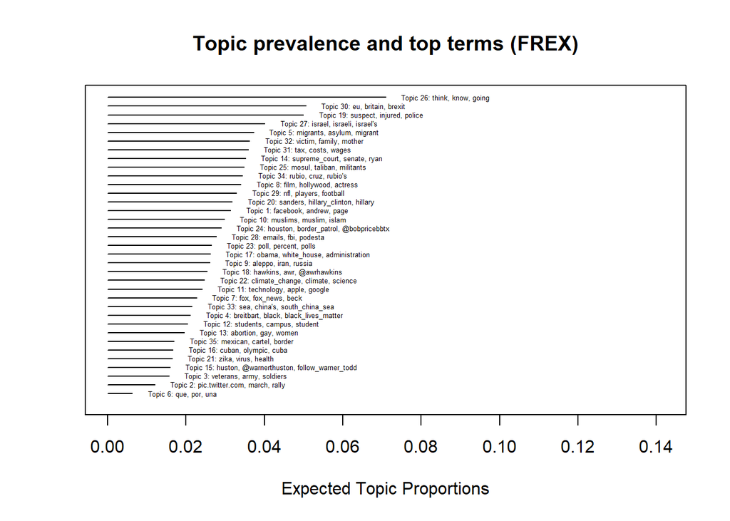

```r
# Plot topic prevalence and top terms per topic by FREX metric
print(plot.STM(stm_model,
         type = "summary",
         labeltype = "frex",
         text.cex = 0.4,
         main = "Topic prevalence and top terms (FREX)"))
```

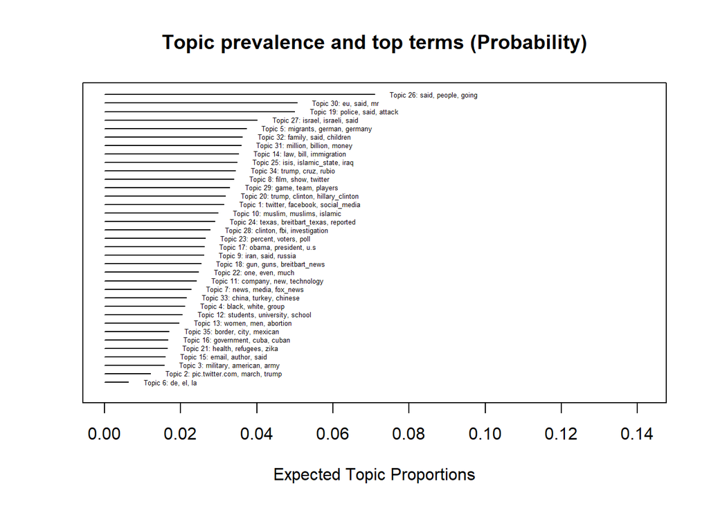

```r
# Plot topic prevalence and top terms per topic by Probability metric
print(plot.STM(stm_model,
         type = "summary",
         labeltype = "prob",
         text.cex = 0.4,
         main = "Topic prevalence and top terms (Probability)"))
```

```r
## Check sample documents with a high probability of containing each topic ##

# Check headline of articles with high probability for Topic 1
findThoughts(stm_model,
             texts = dfm_unsup@docvars$title,
             topics = 1,
             n = 10)
```

```
##
##  Topic 1:
##       Twitter Fixes Reply System After Update ‘Accidentally’ Changes Function for iOS Users
##      Reddit CEO Admits Changing Comments to Direct Users’ Insults at Pro-Trump Moderators
##      Twitter Censors Milo, and Most of the Media Celebrates
##      Facebook Classifying Users as Liberal, Moderate, or Conservative
##      Facebook Denies Reports of Bias Against Conservative News
##      Twitter: Donald Trump’s Account Will Be Banned if He Violates Rules
##      Milo Did Nothing Wrong
##      Facebook Removes Another Popular Comedy Page as Content Creator Revolt Expands
##      Popular Video Game Designer Suspended From Twitter After Islam Tweets
##      Buzzfeed: Twitter Unverifies Breitbart’s Milo Yiannopoulos Amid Speech Wars
```

```r
# Check headline of articles with high probability for Topic 2
findThoughts(stm_model,
             texts = dfm_unsup@docvars$title,
             topics = 2,
             n = 10)
```

```
##
##  Topic 2:
##       Post Debate Surge: Donald Trump Fills Massive Hangar for Florida Rally, Thousands Turned Away
##      Disrupters Fail, Trump Rally Wraps Peacefully in Illinois
##      **LiveWire** Assorted Activists Gather in Manhattan for Day of Protests
##      Two Men Arrested as Fight Breaks Out at Trump Rally in Texas
##      ***Horse Race LiveWire*** Trump: ‘We’re Going to Take Our Country Back from Those People’
##      Donald Trump: San Jose Supporters Were ‘Accosted By A Bunch Of Thugs’
##      ***2016 LiveWire*** Trump Slams ‘Thugs’ Who Accosted His Supporters
##      Hollywood Liberals Blame Trump for Violent Leftwing Protesters Shutting Down Free Speech
##      Donald Trump Venue-Busting Ticket Distribution Worries Vermont Officials
##      Update — Breitbart News Statement: Trump Claim About Michelle Fields ‘Contradicts the Evidence’
```

```r
# Check headline of articles with high probability for Topic 3
findThoughts(stm_model,
             texts = dfm_unsup@docvars$title,
             topics = 3,
             n = 10)
```

```
##
##  Topic 3:
##       The Battle of Kings Mountain: American DNA and Why the Revolution Matters Today
##      The American Way of War: The Battle of Cowpens – Leadership and Adaptability
##      Would You Follow Hillary ‘To Hell and Back?’
##      France Commemorates Centenary of WWI Battle of Verdun
##      Israel to Fly Alongside Pakistan, UAE in US Air Force Drill
##      WATCH: Thousands of Soldiers Place American Flags at Arlington Cemetery for Memorial Day
##      Benghazi Families Push Back Against Clinton for Calling Them Liars
##      America’s Troops Celebrate Christmas Around the World
##      British Warship Docks at Israeli Port Amid Increased Military Cooperation
##      Israeli Students Find Ancient Ballista Ball Used by Jewish Warriors Against Roman Empire
```

```r
# Check headline of articles with high probability for Topic 4
findThoughts(stm_model,
             texts = dfm_unsup@docvars$title,
             topics = 4,
             n = 10)
```

```
##
##  Topic 4:
##       Black Lives Matter Accuses Police of ‘Genocide’ at UC Irvine
##      ‘White Lives Matter’ Protest Features Racist Symbols in Houston
##      Walmart Drops Black Lives Matter ‘Bulletproof’ Clothing
##      Black Lives Matter Protesters Bring London to Standstill Days After Dallas Police Massacre
##      It’s Official: Leftists Failed at Protesting GOP Convention
##      Black Council Member Forced to Apologize for Criticizing Black-On-Black Shootings
##      Obama Hides Anti-Cop Message As ‘War on Cops’ Accelerates
##      Walmart Selling Black Lives Matter Shirts with ‘Bulletproof’ on Them
##      SF Police Must Take Anti-Intolerance Pledge
##      Video Shows Black Lives Matter Protesters Clash with Portland Police
```

```r
# Check headline of articles with high probability for Topic 5
findThoughts(stm_model,
             texts = dfm_unsup@docvars$title,
             topics = 5,
             n = 10)
```

```
##
##  Topic 5:
##       One Third Of ‘Asylum Seekers’ In Capital Are Criminals
##      Norway Security Agency To Liberal Sweden: Muslim Influx Will Bring Problems
##      Syrian Arrivals In Germany To Double As Family Reunification Add 500,000
##      ‘Fleeing War’ Yet Only 7 Per Cent of Asylum Seekers Would Actually Return After Conflict
##      In Austria, Over Half Of All ‘Asylum Seekers’ Commit Crimes
##      Migrant Gang Crime Soars
##      Italy Fears Migrant Wave As 15,000 Reach Its Shores This Week
##      As Norway Begins Organised Deportations, Migrants Go AWOL To Avoid Being Sent To Russia
##      Serbia Prepared For Tougher Border Control After Hungarian Referendum
##      Merkel’s Party, Sliding in Polls, Explores Speedy Repatriation Centres
```

```r
# Check headline of articles with high probability for Topic 6
findThoughts(stm_model,
             texts = dfm_unsup@docvars$title,
             topics = 6,
             n = 10)
```

```
##
##  Topic 6:
##       Celebran Día de Reyes Magos Con Balacera en Matamoros; El Gobierno Trata de Minimizarlo
##      Vídeo: Terror en Ciudad Fronteriza por Balaceras, Gobierno Trata de Minimizar el Caos
##      CONTENIDO GRAFICO: Los Zetas llevan su Guerra Civil de las Calles a las Prisiones
##      Gobierno Mexicano Busca a Víctimas ‘desaparecidas’ y Probablemente Incinerados por Los Zetas
##      El Toro del Cártel del Golfo Escapa Intento de Captura en Ciudad Fronteriza
##      Caza-Zetas Tienen Nuevo Cuartel Cerca de Frontera con Texas
##      Sicarios Chocan Contra Transporte Público Tras Enfrentamiento, Hieren Inocentes
##      GRAFICO Imágenes Exclusivas: Sicarios Queman Vivos a sus Rivales Cerca de la Frontera en Guerra Civil de Los Zetas
##      GRAFICO: Penal de Nuevo León Considerado Bomba de Tiempo por Lucha Interna de Carteles
##      VIDEO: Los Zetas se Enfrentan Entre si, Ejército Mexicano Emboscado cerca de Frontera con Texas
```

```r
# Check headline of articles with high probability for Topic 7
findThoughts(stm_model,
             texts = dfm_unsup@docvars$title,
             topics = 7,
             n = 10)
```

```
##
##  Topic 7:
##       UPDATE–Fox News Chief Fights Back: ‘Roger Ailes Has Never Sexually Harassed Megyn Kelly’
##      Steve Bannon: I Warned Roger Ailes that Megyn Kelly Would Turn On Him
##      Watch Live: Nancy Reagan Funeral at Ronald Reagan Presidential Library
##      Drudge Report: Ailes to Step Down from Fox News, Stay on as 21st Century Fox Consultant Until 2018
##      Report: Glenn Beck’s The Blaze ‘Falling Apart’
##      NYT: Trump’s War on Fox Is About ‘Control Against the Power Structure of the GOP’
##      Roger Ailes vs. the Liberal Sharks — But Which One Could Be Deadly?
##      Michelle Malkin: ‘My Base Is Fed Up with Fox’ News Channel; Murdoch ‘Treacherous Bedfellow’
##      Exclusive– Gretchen Carlson Attorney Donates Big to Left Wing Democrats Who Aggressively Criticize Fox News
##      Breitbart News Daily — Grassroots Rising: Setting the Stage for the GOP Debate
```

```r
# Check headline of articles with high probability for Topic 8
findThoughts(stm_model,
             texts = dfm_unsup@docvars$title,
             topics = 8,
             n = 10)
```

```
##
##  Topic 8:
##       Martha Stewart and Snoop Dogg to Host ‘Dinner Party’ Reality Series
##      George Michael Helped Turn ‘Carpool Karaoke’ into Viral Hit (Video)
##      WATCH: Matt Damon Returns in ‘Jason Bourne’ Trailer
##      Watch: Sony Releases International Trailer for All-Female ‘Ghostbusters’ Reboot
##      Ellen DeGeneres: Transgender Stingray in Disney’s ‘Finding Dory’
##      GRAMMYs Recap: Kendrick Gets Political, Rihanna Cancels, Adele Hurt by CBS Audio Issues
##      WATCH: Darth Vader Returns in Star Wars ‘Rogue One’ Trailer
##      Critics: All-Female ‘Ghostbusters’ an ‘Unfunny Mess’
##      Box Office: ‘Dirty Grandpa’ — Another R-Rated Teen Comedy Flops
##      Don Cheadle: I Want Chris Rock to ‘Take Everybody to Task’ for ‘White Oscars’
```

```r
# Check headline of articles with high probability for Topic 9
findThoughts(stm_model,
             texts = dfm_unsup@docvars$title,
             topics = 9,
             n = 10)
```

```
##
##  Topic 9:
##       Fiercest Airstrikes yet on Aleppo as Syria Declares Offensive
##      Kerry, Lavrov Want to Keep Talking About Syria Despite War Crimes Row
##      Russia Says Still Holding Off on Aleppo Air Strikes
##      Kerry Hopes To Work With Russia On Syria, UN Aims To Restart Talks
##      Syria Army Seizes New Rebel District in Aleppo – Monitor
##      EXCLUSIVE – Senior Arab Diplomat: Saudis See Putin, Not Obama, as Key to Syria’s Future
##      Houthis Make Overtures to Saudi Arabia, Tell Iran to Stay Out of Yemen
##      Iran Denies Providing Missiles to Shiite Houthis in Yemen
##      Kerry in Saudi Arabia for Talks on Yemen, Syria Conflicts
##      Syria Says East Aleppo Ceasefire has Begun, Promises “Safe Exit”
```

```r
# Check headline of articles with high probability for Topic 10
findThoughts(stm_model,
             texts = dfm_unsup@docvars$title,
             topics = 10,
             n = 10)
```

```
##
##  Topic 10:
##       Arab Press: We Muslims Curse Europeans as Racists, Then Blow Up Airports
##      Muslim Writers: Islam To Blame For Global Terror
##      Al-Qaeda to U.S. Muslims: Target ‘Anglo-Saxon Community,’ Avoid Minorities
##      Pope Francis Declares Father Jacques Hamel a Saint, Killing in God’s Name ‘Satanic’
##      Iraqi Journalist Dispels Myth that Islamic State Has No Ties to Islam
##      In Joint Declaration, Pope Francis and Patriarch Kirill Defend Religious Freedom, Marriage, Life of Unborn
##      Pakistani Daily: Islamic State Has No Relation To Islam, Is ‘Creation of America And Europe’
##      The ‘Red-Green Alliance’: A New Anti-Semitism from the Far Left and Islam
##      Rome’s Iconic Trevi Fountain to Be Dyed Red in Honor of New Christian Martyrs
##      Dr. Charles Jacobs: Elitist Self-Loathing Is a ‘Deadly’ ‘Ideological Catastrophe’ for the West in Fighting Radical Islam
```

```r
# Check headline of articles with high probability for Topic 11
findThoughts(stm_model,
             texts = dfm_unsup@docvars$title,
             topics = 11,
             n = 10)
```

```
##
##  Topic 11:
##       Tesla ‘Ludicrous Mode’: 0 to 60 MPH in 2.5 Seconds
##      TESLA: California Regulators to Demand Cease & Desist Advertising “Auto-pilot”
##      Microsoft Introducing VR Headsets at Half the Price of Oculus Rift
##      Former Mozilla CEO Chased Off by SJWs Announces New Internet Browser ‘Brave’
##      Road to E3 2016 Part 1 — Is Microsoft Ready to Unveil a New Console Already?
##      Self-Powering ‘Smart Skin’ Allows Robots to ‘Feel’ the World Around Them
##      Israeli Startup Bets On ‘Smart’ Satellite Antennas For Global Web Access
##      Snapchat Buys Israeli Augmented Reality Startup Cimagine
##      Uber Rolls Out Self-Driving Car in Pittsburgh
##      America Last: 20 American-Born Companies that Have Sold Out to Foreign Interests
```

```r
# Check headline of articles with high probability for Topic 12
findThoughts(stm_model,
             texts = dfm_unsup@docvars$title,
             topics = 12,
             n = 10)
```

```
##
##  Topic 12:
##       Scrapped STAAR Scores Add to Frustrations Over Standardized Testing in Texas
##      University of Chicago Warns Freshmen Not to Expect ‘Trigger Warnings’ and ‘Safe Spaces’
##      Washington State University Professors Argue that Free Speech ‘Hurts’ Marginalized Students
##      College Board’s Common Core Math SAT ‘Wordy Problems’ Hurt Low-Performing Students
##      Princeton Wants Students to Stop Using the Word ‘Man’
##      Task Force Will Focus on Needs of Texas Rural Schools
##      Bucknell Students Demand Financial Aid for Illegal Alien Students
##      Qatar Gives $100,000 to Texas School to Push Arabic Language and Culture
##      Baltimore County School Superintendent Calls For End To ‘GT’ Label
##      Barnard College to Offer 8-week ‘Social Justice Education’ Program
```

```r
# Check headline of articles with high probability for Topic 13
findThoughts(stm_model,
             texts = dfm_unsup@docvars$title,
             topics = 13,
             n = 10)
```

```
##
##  Topic 13:
##       Girl Wants Boy Scout Group to say she is a Transgender Boy
##      Boy Scouts Refuse to Admit Crossdressing Girl
##      Washington Post Reveals Left’s Abortion Hypocrisy
##      Report Claiming Half Of Women Harassed At Work Involved Hardline Feminist Group
##      Archdiocese of St. Louis Severing Ties with Girl Scouts
##      J. Lo Plays Six Different Oppressed Women in Video for Feminist Anthem
##      Oregon Man Becomes Country’s First Legal ‘Gender Non-Binary’
##      Fatwa: Transgender People May Only Marry the Opposite Sex in Pakistan
##      Top London Uni LGBT+ Campaign: Never Call a Stranger He or She
##      One-Third of ‘Pro-Choice’ Women Turn Against Abortion After Viewing Video of Procedure
```

```r
# Check headline of articles with high probability for Topic 14
findThoughts(stm_model,
             texts = dfm_unsup@docvars$title,
             topics = 14,
             n = 10)
```

```
##
##  Topic 14:
##       Senate Judiciary Committee Republicans Vow: No Hearings on Supreme Court Nominee
##      Democrats File Supreme Court Brief In Support of Executive Amnesty
##      Sen. Mike Lee Reaffirms: ‘The American People’ Should Choose Next SCOTUS Nominee
##      Constitution Allows Muslim Immigration Ban
##      Mitch McConnell: Supreme Court Vacancy Should Be Filled After Election
##      Texas Governor Calls for Article V Constitutional Convention
##      Mitch McConnell Can Block Obama Recess Appointment to SCOTUS
##      McConnell Says ‘No’ to Merrick Garland for SCOTUS, Citing ‘Biden Rule’
##      DACA Beneficiary Sues to Exempt N.Y.ers from Injunction Blocking Exec. Amnesty
##      House Republicans Join Democrats to Block Impeachment of IRS Commissioner
```

```r
# Check headline of articles with high probability for Topic 15
findThoughts(stm_model,
             texts = dfm_unsup@docvars$title,
             topics = 15,
             n = 10)
```

```
##
##  Topic 15:
##       Group in Mississippi Protests Target’s Pro-Transgender Bathroom Policy
##      Group Offers Top Ten Christian-Friendly Stores for Parents Who Oppose Target’s Transgender Promotion
##      Pro-Family Group Launches #BoycottTarget Movement over Transgender-Friendly Bathroom Policy
##      Chipotle Mexican Restaurant Being Sued for Making Customers ‘Too Full’
##      Target Spends $20 Million on One-Person Bathrooms After Transgender Stunt Sparks Boycott
##      Before Pushing Transgender Bathrooms, Target Hired Former La Raza Executive as Board Member
##      Muslim Employees at Wisconsin Company Upset over Prayer-Time Cancellation
##      Jordan Brown Admits Hoax After Accusing Whole Foods of Gay Slur
##      Man Accused of Peeping in Women’s Restroom Also Faces Child Porn Charges
##      Target’s Stock Down 5 Percent, Brand Damaged, by Public Rebuke to Pro-Transgender Bathroom Rules
```

```r
# Check headline of articles with high probability for Topic 16
findThoughts(stm_model,
             texts = dfm_unsup@docvars$title,
             topics = 16,
             n = 10)
```

```
##
##  Topic 16:
##       First Argentina, Then Brazil: Cuba Is Losing All Its Friends
##      Cuba Arrested Nearly 500 Political Dissidents During Obama Visit
##      Olympics Chaos: Staffers Sold Tickets for Seats That Don’t Exist
##      Six U.S. Airlines to Begin Flights to and from Cuba
##      Sour Grapes in Havana as Exiles Outshine Cuba’s Olympic Team
##      Colombia: FARC Terrorists May Have Forced Retirement of Brigadier General
##      Rio Cops Seize Bags of Cocaine Using Olympic Logo on Them as Marketing Gimmick
##      Man Bikes from Argentina to Rio de Janeiro Olympics — Bike Gets Stolen
##      ‘We Are Slaves in Lab Coats’: Cuban Doctor Reunites with Mother After Flight to U.S.
##      White House Vetoes Cuban Anti-Communist Jazz Legend’s Invite, Later Calls it ‘Error’
```

```r
# Check headline of articles with high probability for Topic 17
findThoughts(stm_model,
             texts = dfm_unsup@docvars$title,
             topics = 17,
             n = 10)
```

```
##
##  Topic 17:
##       Charity Still Needs ‘Few Thousand Wreaths’ to Cover All Headstones in Arlington National Cemetery
##      Trump Transition Update: Meeting with Henry Kissinger, Nikki Haley, Rick Scott and More
##      Stephen Miller to Write Trump’s Inaugural Speech
##      Trump Team Blasts Politico Report on Private Security: ‘Complete Nonsense’
##      POLITICO: Artlington Cemetery: A Year in Pictures
##      CitiGroup: Major Sponsor of Refugee Advocate Gathering to Plan Opposition to Trump Policies
##      Wikileaks: Obama Transition Team Member Resigns After Being Ignored on ‘Badly Broken’ DHS
##      President-Elect Trump Appoints Stephen Miller Senior Advisor to the President for Policy
##      Making His Demands: Obama Summons Paul Ryan And Mitch McConnell For Meeting
##      Hacked Soros Memo: $650,000 to Black Lives Matter
```

```r
# Check headline of articles with high probability for Topic 18
findThoughts(stm_model,
             texts = dfm_unsup@docvars$title,
             topics = 18,
             n = 10)
```

```
##
##  Topic 18:
##       California Assemblyman: Universal Background Checks Not Enough, Must Video Every Gun Sale
##      California Passes ‘Gunpocalypse’: War on 2nd Amendment
##      South Dakota to Let Concealed Permits Replace Background Check Requirement
##      Joe Biden: Ban ‘Civilian Ownership’ Of ‘Assault Weapons’
##      ATF: Omar Mateen Bought Guns ‘Legally’
##      CNN’s Sandy Hook Lawsuit Report Omits Crucial Detail: Adam Lanza Stole His Guns
##      Not A Happy Thanksgiving: 70 Shot in Gun-Controlled Chicago Over Holiday Weekend
##      California Sheriffs Unite in Opposition to Gavin Newsom’s Gun Control
##      Minnesota House Rejects Universal Background Checks
##      Gov. McAuliffe Reverses Course: Restoring Concealed Carry Reciprocity with 25 States
```

```r
# Check headline of articles with high probability for Topic 19
findThoughts(stm_model,
             texts = dfm_unsup@docvars$title,
             topics = 19,
             n = 10)
```

```
##
##  Topic 19:
##       ‘Allahu Akbar’: Belgian Police Officers Injured in Machete Attack
##      Gunman Shot By Police After Opening Fire In Belgian City
##      Elderly Woman Shot and Killed Inside Grocery Store in Philadelphia
##      Police: 4 Dead in Seattle-Area Mall Shooting, Gunman on the Loose
##      Belgian Prime Minister Returns From Holiday, Says Machete Attack ‘May Be Terrorism’
##      Terror Attack Thwarted, Bombs Found in Downtown Jerusalem
##      Israeli Teen Stabbed in Back Outside Old City’s Damascus Gate
##      France Attacker Visited Site With Truck Twice: Investigative Source
##      13 Dead And 6 Injured As Fire Engulfs Bar In France
##      Brussels Airport Suspect: Bombers Planned to Target Tel Aviv Passengers
```

```r
# Check headline of articles with high probability for Topic 20
findThoughts(stm_model,
             texts = dfm_unsup@docvars$title,
             topics = 20,
             n = 10)
```

```
##
##  Topic 20:
##       ‘Plan B’: Green Party’s Jill Stein Reaches Out to Sanders Supporters
##      DNC Admits that Republicans Are the Party of Donald Trump
##      ***Live Updates*** Clinton, Sanders Face Off in First Head-to-Head Debate
##      ***Live Updates*** Dems Hold Sunday Evening Debate in South Carolina
##      Exclusive: ‘Black Men for Bernie’ Founder to End Democrat ‘Political Slavery’ of Minority Voters… by Campaigning for Trump
##      ‘Rigged’ Message Gains Steam, Donald Trump Catching Up to Hillary Clinton in Latest Reuters Poll
##      L.A. Times Columnist Worries: ‘Crooked Hillary’ May Stick
##      Clinton Cash: Hillary Rakes in Nearly $70 Million in June
##      Leeson: Word ‘Again’ Holds Power in America Today
##      Bill Clinton Calls for ‘Shared Prosperity’ with Hillary Clinton
```

```r
# Check headline of articles with high probability for Topic 21
findThoughts(stm_model,
             texts = dfm_unsup@docvars$title,
             topics = 21,
             n = 10)
```

```
##
##  Topic 21:
##       One in Four Refugees Sent to Tennessee Carry Tuberculosis
##      Dallas County Confirms First West Nile Virus Fatality of 2016
##      Brazil Confirms Case of Zika Infection by Blood Transfusion
##      Zika: CDC Hits the Panic Button
##      Zika Virus Reaches San Francisco
##      More Zika Reported in Texas as 2016 Winds Down
##      Zika: Aerial Spraying and Releasing Bats Approved
##      Zika: CDC Warns Pregnant Women to Avoid Travel to Miami
##      Study Links Zika to Brain Damage in Adults
##      Refugee Public Health Controversy in Michigan
```

```r
# Check headline of articles with high probability for Topic 22
findThoughts(stm_model,
             texts = dfm_unsup@docvars$title,
             topics = 22,
             n = 10)
```

```
##
##  Topic 22:
##       Bill Nye and Scientism
##      Study: West Antarctic – Poster Child of Global Warming – is Getting Colder
##      Climate Scientists: Antarctic Temperatures Cooling Every Year Since 1998
##      Esquire Panic! Global Warming Creating ‘Vast Deserts’
##      When You Hear a Scientist Talk About ‘Peer Review’ You Should Reach For Your Browning
##      Ocean Acidification: Your Chance To Help Kill This Dodgy Scam Once And For All!
##      Global Temperatures Plunge. Icy Silence from Climate Alarmists
##      Cows Worse Than Cars for Climate Change, Environmentalists Admit
##      Icegate: Now NSIDC Caught Tampering With Climate Records
##      Attorney General Loretta Lynch Wants to Prosecute ‘Deniers’: Here’s Why She’ll Fail
```

```r
# Check headline of articles with high probability for Topic 23
findThoughts(stm_model,
             texts = dfm_unsup@docvars$title,
             topics = 23,
             n = 10)
```

```
##
##  Topic 23:
##       Latinos Desert Sanchez for Harris in California Senate Race
##      ‘Vote by Mail’ Ballots Sent in California Primary
##      Flood of GOP Senate Candidates Boosts Odds of Double Democrat Showdown in California
##      Donald Trump Won 7.5 Million Popular Vote Landslide in Heartland
##      Poll: Only 13 Percent of Democrats Enthusiastic About Their Party’s Future
##      Obama’s Approval Rating Increases to 55 Percent
##      Early L.A. County Voter Turnout Trumping 2012 by 350%
##      Poll: Trump Lead in South Carolina Drops to 5
##      Los Angeles: Nearly 1 Million Voters Have No Republicans Down-ticket
##      Donald Trump Maintains Lead in Latest Missouri Poll
```

```r
# Check headline of articles with high probability for Topic 24
findThoughts(stm_model,
             texts = dfm_unsup@docvars$title,
             topics = 24,
             n = 10)
```

```
##
##  Topic 24:
##       Alleged Rapist Arrested During Drug Smuggling Attempt
##      Texas Woman Uses Infant Child to Smuggle Meth From Mexico
##      Feds Seize Nearly $2 Million in Meth at Texas-Mexico Border
##      $7 Million in Meth Seized by Border Patrol Agents in Texas
##      Feds Stop Meth, Human Smuggling in Arizona Over Weekend
##      $500K in Cocaine, Marijuana Seized in 3 Arizona Busts
##      Captured Illegal Immigrant Child Predator Sent to ‘Sanctuary’ Texas County
##      FBI Informant Helps Bust Massive Tennessee Meth Ring
##      Previously Deported Illegal Alien Rapist Captured in California
##      3 Men Indicted for Attempted Assassination of Texas Judge, Says FBI
```

```r
# Check headline of articles with high probability for Topic 25
findThoughts(stm_model,
             texts = dfm_unsup@docvars$title,
             topics = 25,
             n = 10)
```

```
##
##  Topic 25:
##       Mosul Operation: Islamic State Using Thousands as Human Shields
##      Islamic State Video Praises Successes of Boko Haram in Niger
##      Mosul: Anti-Islamic State Coalition ‘Cratering’ Roads to Stop Suicide Bombers
##      Iraqi Forces Launch Military Operations to Liberate Mosul From Islamic State
##      Rights Group: Islamic State in Mosul Targets Civilians as it Retreats
##      Report: Islamic State May Use ‘Human Shields’ to Defend Libyan Stronghold Sirte
##      Afghan President Ashraf Ghani: ‘We Will Bury’ Islamic State
##      WATCH: Iraqi Civilians Swim Across Euphrates to Escape Islamic State
##      Niger: 31 Boko Haram Jihadists Surrender, Expect Pardon
##      Mosul: Iraqi Army Retakes State TV Station After Heavy ‘Street Fighting’
```

```r
# Check headline of articles with high probability for Topic 26
findThoughts(stm_model,
             texts = dfm_unsup@docvars$title,
             topics = 26,
             n = 10)
```

```
##
##  Topic 26:
##       Bungie Confirms Endgame Matchmaking Isn’t Coming with ‘Destiny: Rise of Iron’
##      Glenn Beck’s Farewell Address to His 40 Laid-Off Troops… from His Pretend Oval Office
##      Glenn Beck and Samantha Bee Bond Over Their Fear and Loathing of Trump
##      Arizona Woman Removed from Life Support Lives to Tell Story
##      Apologize For What? Curt Schilling Stands Strong Against Left on Transgender Bathroom Comments
##      Dad Whose Son Was Killed by Illegal: Ted Cruz Angrier About Donald Trump Tweets Than Illegal Immigrant Killers
##      Milo vs Ann Coulter on Donald Trump’s Mischievous Late-Night Tweets
##      EXCLUSIVE – Jackie Mason Slams Mitt Romney For Interest in State Job After Repeatedly Criticizing Donald Trump
##      ‘Mmm Mmm Mmm’ Michelle Obama Describes The Good Times At The White House
##      Sharyl Attkisson: Brexit Support Was ‘Largely Censored from the Mainstream Media’
```

```r
# Check headline of articles with high probability for Topic 27
findThoughts(stm_model,
             texts = dfm_unsup@docvars$title,
             topics = 27,
             n = 10)
```

```
##
##  Topic 27:
##       Palestinians Stage UN Showdown Over Israeli Settlements
##      Five Reasons Obama Targeting Israel At The United Nations Would Reward Palestinian Extremism
##      Following Palestinian Terror Rampage, Israel Okays 800 New Homes in and Near Eastern Jerusalem
##      Hamas Threatens To ‘Surprise The World’ With Prisoner Exchange Deal
##      State Department: We ‘Strongly Oppose’ Jews Building in Eastern Jerusalem
##      Report: Kerry Told Netanyahu U.S. Undecided on UN Resolution
##      Watch: Netanyahu and Abbas Shake Hands at Peres Funeral
##      Israeli Defense Minister Avigdor Liberman Likens Upcoming Paris Mideast ‘Peace’ Summit to Anti-Semitic Dreyfus Affair
##      Hamas Official Downplays Discovery of Attack Tunnel in Israel
##      Hamas Claims Tunnel Inside Israel ‘Only A Small Part’ of Battle Plans Against Jewish State
```

```r
# Check headline of articles with high probability for Topic 28
findThoughts(stm_model,
             texts = dfm_unsup@docvars$title,
             topics = 28,
             n = 10)
```

```
##
##  Topic 28:
##       Report: Concerned State Dept Employees Told to ‘Never Speak of’ Hillary’s Server
##      House Oversight Chair Chaffetz Issues Subpoena to FBI for All Clinton Email Investigation Documents
##      Clinton Foundation Fears It Was Hacked, Hires Cyber Security Firm
##      Gedrich: Blame Clinton, Not Comey, for Email Woes
##      Report: At the FBI, ‘Incredulity at what Is Being Discovered’ in Hillary Clinton’s Emails
##      EXCLUSIVE: Former RNC Chairman: Evidence Shows Hillary Clinton Never Qualified For Security Clearance
##      Hillary Clinton Deleted More Emails Than She Sent to the State Department
##      Clinton Wrote 104 of the Classified Emails Discovered on Her Server
##      Hillary Clinton Campaign Meltdown: Top-Secret Emails ‘Innocuous,’ Should Be Released
##      FBI IRS Scandal Documents: Obama IRS Waited Years to Tell Truth
```

```r
# Check headline of articles with high probability for Topic 29
findThoughts(stm_model,
             texts = dfm_unsup@docvars$title,
             topics = 29,
             n = 10)
```

```
##
##  Topic 29:
##       Royce Gracie Beats Ken Shamrock in Controversial Stoppage at Bellator 149
##      Angel Plays Devil to Wichita State Tourney Run
##      NFL Preview: Pats Look to Stay on Top Post-Gronk, Giants Travel to Pittsburgh, Chiefs Battle Falcons
##      NFL Preview: Is Colin Kaepernick Playing Himself Out of the League?
##      Trevor Story Sets Record in Hitting 7th HR Through Season’s 1st 6 Games
##      Peyton Manning Compiles Fewest Passing Yards of Any Winning SB QB Since Terry Bradshaw
##      Cavs-Warriors Game 7 All Time Highest Rated NBA Broadcast for ABC
##      King James Dethroned as Ruler of NBA Jersey Sales
##      NFL Preview: No Debate, No World Series, No Excuses If Broncos-Raiders Doesn’t Get Gangbuster Ratings
##      Georgetown Road Upset of Xavier Brings Point Guard Closer to Big East Immortality
```

```r
# Check headline of articles with high probability for Topic 30
findThoughts(stm_model,
             texts = dfm_unsup@docvars$title,
             topics = 30,
             n = 10)
```

```
##
##  Topic 30:
##       More Than 2,000 Sign Petition Demanding Douglas Carswell Resign From UKIP After ‘Coup’
##      EU Meets Without Britain For First Time Since Brexit Vote
##      Brexit Referendum Forces EU Summit Delay
##      Tory Cabinet Minister Says Staying in an Unreformed EU Would Be ‘Disastrous’
##      Brexit Minister: We Will Reject Any Attempt To Delay EU Exit
##      Marine Le Pen in Euro Parliament: ‘UK Sent A Signal Of Freedom Out To The Entire World’
##      Cameron Claims ‘More to be Done’ As EU Chief Reveals ‘Watered Down’ Migrant Benefits Deal
##      Poland’s Populists Panic, Ask Britain To Hold Second Referendum
##      Who’s ‘Nexit’? As The ‘Patriot Spring’ Sweeps The Continent, Europeans Call For Their Own Referendums
##      Italian PM Says Brits Cannot Expect More Rights than Other Non-EU Citizens
```

```r
# Check headline of articles with high probability for Topic 31
findThoughts(stm_model,
             texts = dfm_unsup@docvars$title,
             topics = 31,
             n = 10)
```

```
##
##  Topic 31:
##       Federal Reserve Could Push Economy into Another Recession
##      Morici: Federal Reserve Should Stick to a Schedule to Raise Rates
##      Oil Prices Plunge and Stocks Hit Lowest Level Since 2014
##      Crude Oil Price Still Crashing Toward $25
##      Morici: Donald Trump’s Economy Will Benefit Ordinary Investors
##      As Israel’s Tech Sector Booms, its Pension Funds Miss Out
##      China’s Market Chaos: Obama Should Lift Page from Trump to Avert Crisis
##      U.S. Economy Accelerates with 287,000 Jobs in June
##      OPEC Agrees to Production Decrease, Prices Increase
##      Expert: Wages Drop in Jobs With Many Foreign Guest-Workers
```

```r
# Check headline of articles with high probability for Topic 32
findThoughts(stm_model,
             texts = dfm_unsup@docvars$title,
             topics = 32,
             n = 10)
```

```
##
##  Topic 32:
##       Brexit Voter Died Hours After Brutal Attack by Remain Supporter
##      Rotherham Abuse Trial: Defendant Was Police Cadet When Alleged Offences Occurred
##      Colorado Woman Sentenced to 100 Years for Cutting Baby from Stranger’s Womb
##      Man Sentenced to Life in Prison for Cutting Out Girlfriend’s Lung While She Was Still Alive
##      6-Year-Old Rescues Ducklings from Drainpipe
##      ‘Keep A Diary’: Police Advice To 12-Year-Old Rape Victim Still Being Abused By Attacker’s Family And Friends
##      Texas Kids Chained to Fence Show Long History of Abuse
##      Pakistani Girl Marries for Love, Gets Incinerated by Mother
##      Rotherham Child Abuse Gang Sentenced for Raping 16 Girls
##      West Virginia Infant Dies After Vicious Sexual Assault
```

```r
# Check headline of articles with high probability for Topic 33
findThoughts(stm_model,
             texts = dfm_unsup@docvars$title,
             topics = 33,
             n = 10)
```

```
##
##  Topic 33:
##       U.S. Intel Director: China to Keep Pushing Illegal South China Sea Boundaries
##      U.S. Canceled Anti-China ‘Freedom of Navigation’ Operation in South China Sea
##      Intelligence Chief: China Will Have ‘Substantial Military Power’ in South China Sea by 2017
##      U.S. Navy Plans More Military Exercises of ‘Greater Complexity’ in South China Sea
##      Vietnam Challenges China with Bigger Military Facilities in South China Sea
##      World View: China’s Military Deploys Bombers and Closes Part of the South China Sea
##      South China Sea: China Denies U.S. Aircraft Carrier Permission to Visit Hong Kong
##      John Kerry Promises ‘Very Serious’ Talk with China on Missiles in South China Sea
##      Report: China Building Reinforced Hangars on Disputed Islands
##      World View: Australia’s Defense Plans Stress Huge Naval Buildup Targeting China
```

```r
# Check headline of articles with high probability for Topic 34
findThoughts(stm_model,
             texts = dfm_unsup@docvars$title,
             topics = 34,
             n = 10)
```

```
##
##  Topic 34:
##       McCain ‘Cronies’ Show ‘True Colors’ in Palin Attack Says Primary Challenger Kelli Ward
##      Donald Trump: ‘Mixed up Man’ Mitt Romney’s Vote for Ted Cruz Is ‘Good for Me’
##      Club For Growth PAC Makes First Ever Presidential Endorsement with Ted Cruz
##      Establishment Nightmare: Team Kasich Fires at Marco Rubio After Nevada
##      Nevada: Ben Carson Focused on Reno
##      Donald Trump Crushes ‘Little Marco’ in His Home State of Florida with Embarrassing Defeat for Rubio
##      Mike Huckabee: Ted Cruz’s Tactics ‘Cheap;’ ‘Low Life, Sleazy Politics’
##      Ted Cruz Has Raised $3 Million Since Iowa Caucus
##      Donald Trump on Ted Cruz Debate Challenge: ‘Can We Do It in Canada?’
##      Report: Rick Santorum to End Presidential Campaign
```

```r
# Check headline of articles with high probability for Topic 35
findThoughts(stm_model,
             texts = dfm_unsup@docvars$title,
             topics = 35,
             n = 10)
```

```
##
##  Topic 35:
##       El Chapo: A Momentary Distraction for a Country in Flames
##      Mexigate: Border Politicos Caught Stealing Files from Government Building
##      Mexico’s Case of 43 Missing Students in Hands of El Chapo’s Friend, Wedding Guest
##      Mexican Clergy Call for Dialogue with Drug Cartels, Governor Calls for Media Silence
##      Federales Tout Victories Against Crime, Fiddle on While Mexico Burns
##      Corruption, Ties to Organized Crime Taint Mexican Border State Elections
##      DEA Fugitive Praised by Mexican Newspaper that Misled Voters About Corrupt Candidate
##      EXCLUSIVE — Feds Capture Los Zetas Cartel Boss in Houston
##      Foreigners Gather in Droves at Border to Illegally Enter U.S.
##      Mexican Border State Working the Media to Hide Narco-Image
```

```r
# Check text of articles with high probability for Topic 26
findThoughts(stm_model,
             texts = dfm_unsup@docvars$text,
             topics = 26,
             n = 10)
```

```
##
##  Topic 26:
##       At this year’s E3, I interviewed Bungie’s Scott Taylor on co-operative shooter ,Destiny’s, new expansion, Rise of Iron,, player concerns, and hints toward the game’s inevitable sequel.,It was a challenging interview, setting myself opposite both Scott and a Bungie PR representative, working…
##      In a special video ,posted to his website, today, Glenn Beck addressed news reports of the latest mass layoffs at his troubled media empire.,According to ,a report yesterday in the Daily Beast,, Beck laid off 40 employees of his Blaze media organization “in order to satisfy the requirements …
##      TheBlaze founder Glenn Beck ,interviewed, ,Full Frontal, host Samantha Bee on his show Thursday as the first part in an effort between the rightwing talker and the leftwing comedian to find common ground.,“We’re doing a piece with Glenn,” Bee said. “And so you [Beck] generously invited me to…
##      Doctors told an Arizona woman’s family to take her off life support; she woke from her coma, to the surprise of everyone around her.,“Everything can be taken away. You can wake up one day and everything is fine, and then your life is a mess,” ,said Steven Pellettiere-Swapp,. “Keep your famil…
##      Curt Schilling, the ex-Boston Red Sox ace pitcher, appeared on Breitbart News Daily on SiriusXM 125 The Patriot Channel with host and Breitbart News Executive Chairman Stephen K. Bannon on Friday morning to make absolutely clear he is not backing down to the left over his transgender bathroo…
##      “It’s like we’ve got a voice now. People are listening,” says 53-year-old Billy Inman, whose teenage son was murdered by an illegal alien nearly sixteen years ago. “Donald Trump gives us a little bit of hope. … For years, I’d talk to our ‘elected ones,’ and it was like talking to a wall … [b…
##      Ann Coulter and ,Breitbart ,senior editor Milo Yiannopoulos have a lot in common. Both blonde, both conservative firebrands, both ardent defenders of GOP presidential candidate Donald Trump. But the two have a difference of opinion on the frontrunner’s relentless crassness on social media.,I…
##      During a radio interview on Sunday, comic legend Jackie Mason blasted Mitt Romney for his reported interest in serving as Secretary of State after repeatedly criticizing President-elect Donald Trump during the recent presidential campaign.,Stated Mason: “Can you imagine going to a guy’s offi…
##      “Mmm mmm mmm.”,That’s what life at the White House can be like for First Lady Michelle Obama.,During an interview with Oprah Winfrey at the White House United State of Women summit, Oprah asked her “what are those days when you just say, mmm, mmm, mmm, look at me in the White House.”,Obama c…
## She also mentioned her mother and daughters talking to Pope Francis as an “Mmm, mmm, mmm” moment as well as dinner with the Queen of England.,“You know, you try to play these moments off, like oh, yes, yes, I know what I’m doing,” she said. “And inside you’re going, mmm, mmm, mmm.”,Oprah Winfrey …
##      Sharyl Attkisson of ,Full Measure, told ,Breitbart News Daily, SiriusXM host Stephen K. Bannon that “if the media is this shocked” over last night’s Brexit vote, “that means they aren’t really good listeners, or predictors, or measurers of what’s happening on the ground. That’s kind of basic…
```

Labels were attributed to each identified topic, informed by a review of terms with the highest probability, but primarily by terms with highest FREX (frequency and exclusivity - indicating terms that “distinguish” a topic).

For better interpretation, each topic was also explored in further detail by checking headlines and/or text for articles with a high probability of containing the topic, to get a better idea of the frequent terms when used in context, and topic labels were amended accordingly.

Topic prevalence over time was also plotted to explore any temporal patterns that might aid in interpretation. For example, interpretation of Topic 34 (GOP primary candidates) was helped by noting the high prevelance during Q1-2 of 2016, when primary elections were taking place.

Below is a list of the final labels, ranked by overall topic prevalence as identified by the plots:

- Topic 26: Interviews / direct speech
- Topic 30: Britain / Brexit
- Topic 19: Deadly incidents / terrorist attacks / shootings
- Topic 27: Israel / Palestine
- Topic 5: European immigration
- Topic 32: Criminal trials
- Topic 31: Economy
- Topic 14: Supreme Court / Judiciary
- Topic 25: Islamic extremist groups
- Topic 34: Republican party primary candidates
- Topic 8: Celebrities
- Topic 29: Sports
- Topic 20: Democratic election candidates
- Topic 1: Social media platforms
- Topic 10: Sectarianism / Religious persecution
- Topic 24: Breitbart Texas correspondents
- Topic 28: Hillary Clinton email controversy & investigation
- Topic 23: Elections and polls
- Topic 17: Obama-Trump interaction / transition of power
- Topic 9: Syrian/Yemeni civil war
- Topic 18: Gun control
- Topic 22: Climate change
- Topic 11: Tech industry
- Topic 7: Fox news
- Topic 33: International territorial disputes / border conflicts / South China Sea
- Topic 4: BLM / Race relations / police brutality
- Topic 12: Education
- Topic 13: Gender & LGBT issues
- Topic 35: Mexico
- Topic 16: Latin American left-wing administrations
- Topic 21: Public health
- Topic 15: Warner Todd Huston articles / bathroom gender policy (possibly junk)
- Topic 3: US armed forces
- Topic 2: Trump rallies
- Topic 6: Spanish language news

*Note: a review of samples of full article texts was carried out for several more topics, but I did not include here to save space.

4. Topic model validation. Demonstrate and interpret the semantic and predictive validity of the model. Also discuss the quality of topics in terms of semantic coherence and top exclusivity. Discuss how you would show construct validity.

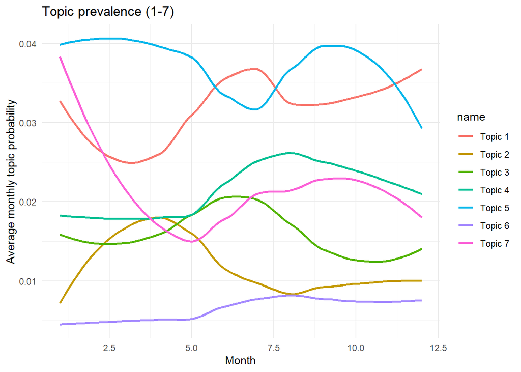

```r
## Predictive Validation: plot topic probabilities over time ##

# Convert metadata to correct format
stmdfm$meta$num_month <- month(stmdfm$meta$date)

# Aggregate topic probability by month
agg_theta <- setNames(aggregate(stm_model$theta,
                                by = list(month = stmdfm$meta$num_month),
                                FUN = mean),
                      c("month", paste("Topic",1:35)))
agg_theta <- pivot_longer(agg_theta, cols = starts_with("T"))

# Aggregate topic probability by month (Topic 1-7)
agg_theta1 <- agg_theta[agg_theta$name %in% c("Topic 1", "Topic 2", "Topic 3",
                                               "Topic 4", "Topic 5", "Topic 6",
                                               "Topic 7"),]

# Aggregate topic probability by month (Topic 8-14)
agg_theta2 <- agg_theta[agg_theta$name %in% c("Topic 8", "Topic 9", "Topic 10",
                                              "Topic 11", "Topic 12", "Topic 13",
                                              "Topic 14"),]

# Aggregate topic probability by month (Topic 15-21)
agg_theta3 <- agg_theta[agg_theta$name %in% c("Topic 15", "Topic 16", "Topic 17",
                                              "Topic 18", "Topic 19", "Topic 20",
                                              "Topic 21"),]

# Aggregate topic probability by month (Topic 22-28)
agg_theta4 <- agg_theta[agg_theta$name %in% c("Topic 22", "Topic 23", "Topic 24",
                                              "Topic 25", "Topic 26", "Topic 27",
                                              "Topic 28"),]

# Aggregate topic probability by month (Topic 29-35)
agg_theta5 <- agg_theta[agg_theta$name %in% c("Topic 29", "Topic 30", "Topic 31",
                                              "Topic 32", "Topic 33", "Topic 34",
                                              "Topic 35"),]

# Plot aggregated theta over time (Topic 1-7)
print(ggplot(data = agg_theta1,
       aes(x = month, y = value, group = name)) +
  geom_smooth(aes(colour = name), se = FALSE) +
  labs(title = "Topic prevalence (1-7)",
       x = "Month",
       y = "Average monthly topic probability") +
  theme_minimal())
```

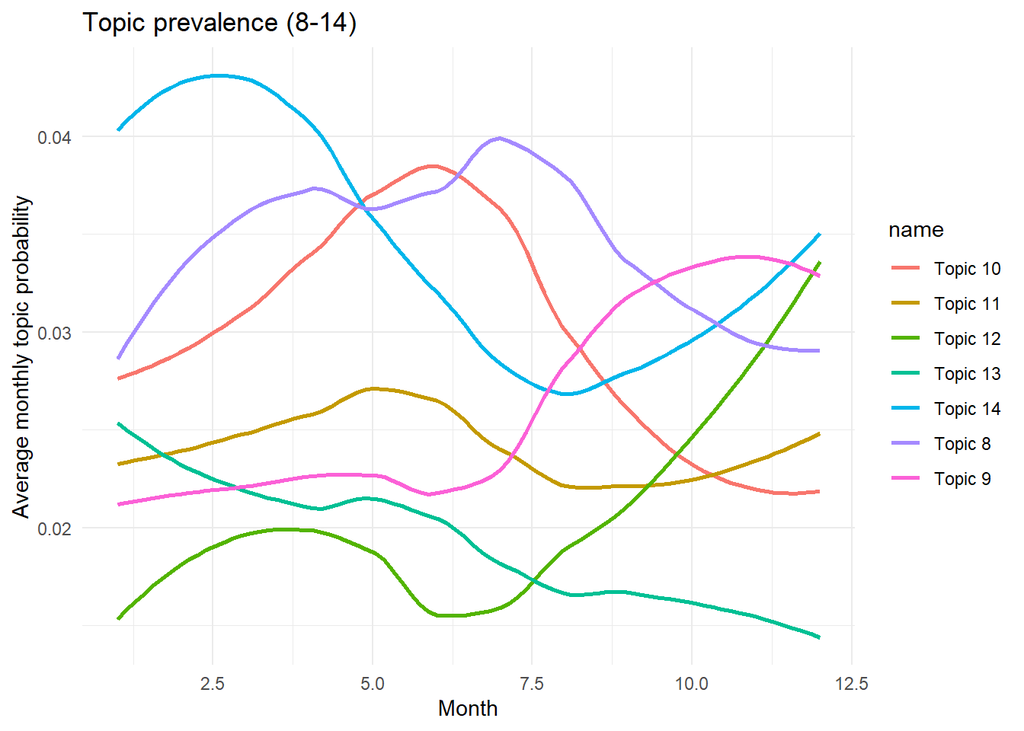

```r
# Plot aggregated theta over time (Topic 8-14)
print(ggplot(data = agg_theta2,
       aes(x = month, y = value, group = name)) +
  geom_smooth(aes(colour = name), se = FALSE) +
  labs(title = "Topic prevalence (8-14)",
       x = "Month",
       y = "Average monthly topic probability") +
  theme_minimal())
```

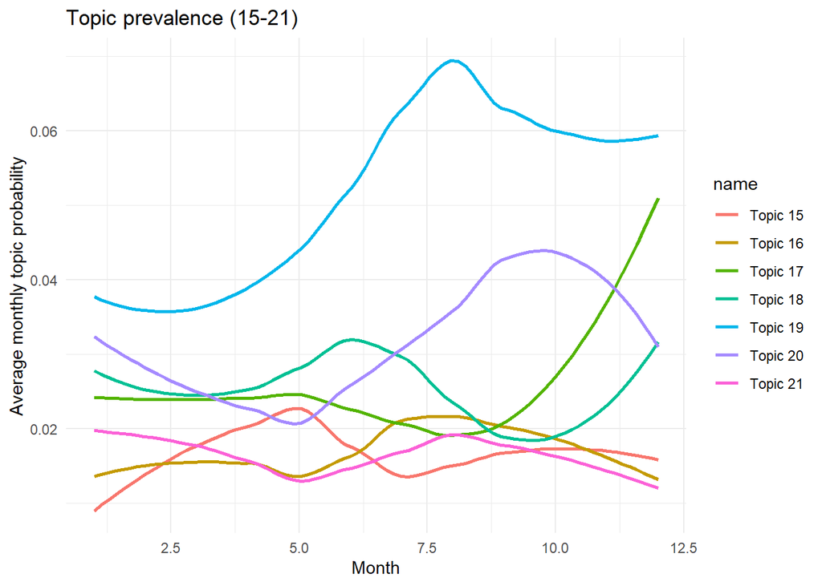

```r
# Plot aggregated theta over time (Topic 15-21)
print(ggplot(data = agg_theta3,
       aes(x = month, y = value, group = name)) +
  geom_smooth(aes(colour = name), se = FALSE) +
  labs(title = "Topic prevalence (15-21)",
       x = "Month",
       y = "Average monthly topic probability") +
  theme_minimal())
```

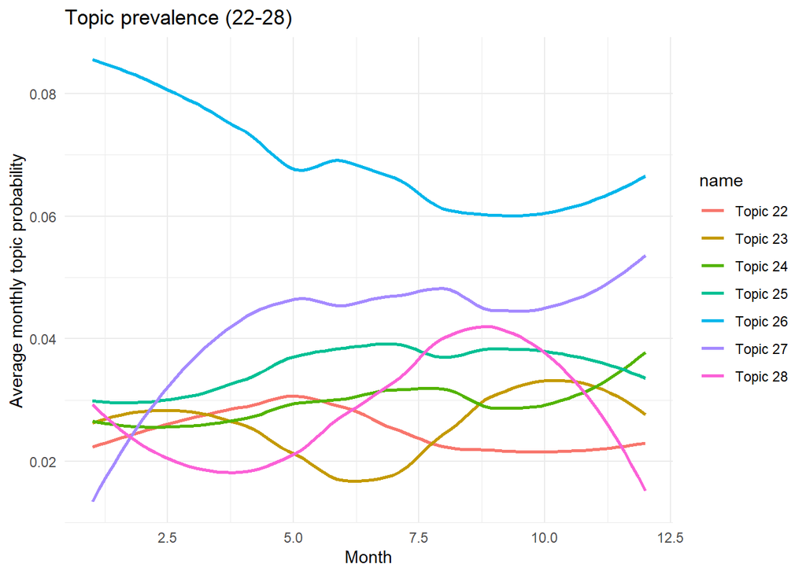

```r
# Plot aggregated theta over time (Topic 22-28)
print(ggplot(data = agg_theta4,
       aes(x = month, y = value, group = name)) +
  geom_smooth(aes(colour = name), se = FALSE) +
  labs(title = "Topic prevalence (22-28)",
       x = "Month",
       y = "Average monthly topic probability") +
  theme_minimal())
```

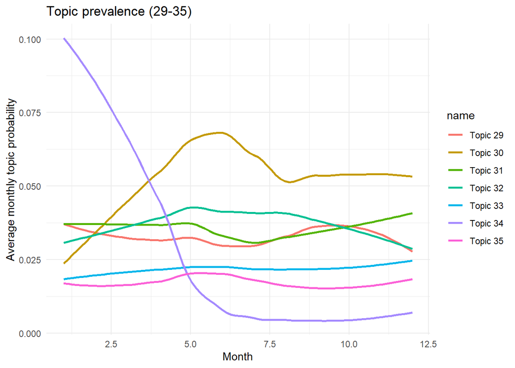

```r
# Plot aggregated theta over time (Topic 29-35)
print(ggplot(data = agg_theta5,
       aes(x = month, y = value, group = name)) +
  geom_smooth(aes(colour = name), se = FALSE) +
  labs(title = "Topic prevalence (29-35)",
       x = "Month",
       y = "Average monthly topic probability") +
  theme_minimal())
```

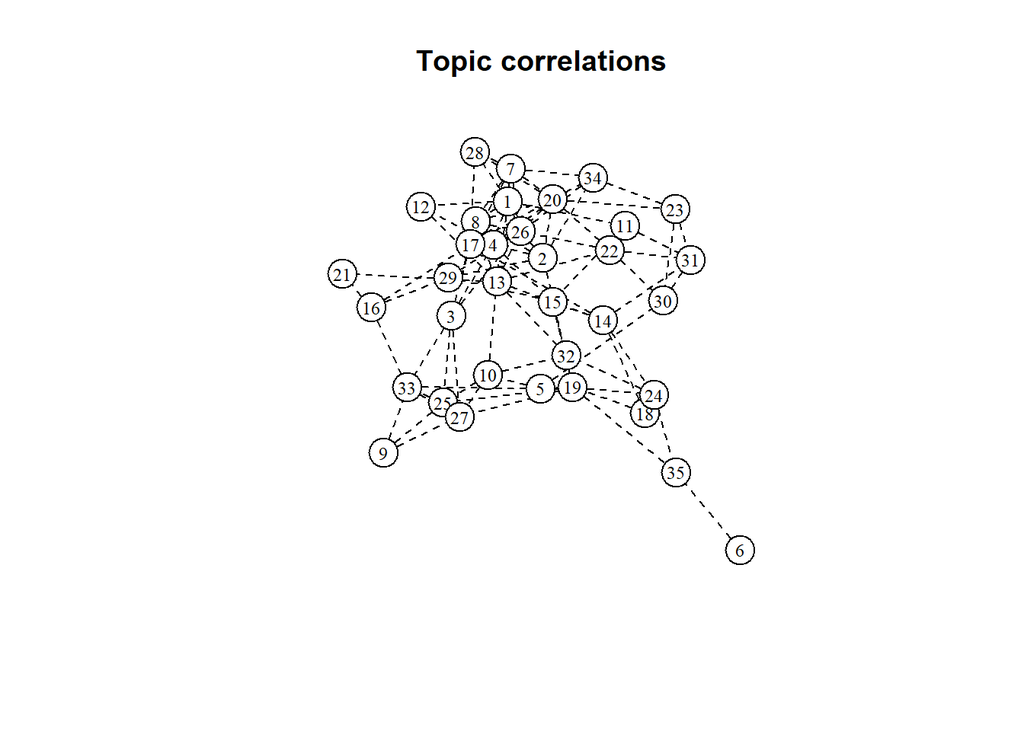

```r
## Semantic validation: plot topic correlations
topic_correlations <- topicCorr(stm_model)
plot.topicCorr(topic_correlations,
               vlabels = seq(1:ncol(stm_model$theta)),
               vertex.color = "white",
               main = "Topic correlations")
```

```
##  [1] -202.9225 -222.3021 -193.9988 -210.9630 -133.0942 -133.4051 -213.1804
##  [8] -268.8833 -223.8402 -217.3533 -224.4124 -219.6088 -243.5675 -228.7122
## [15] -363.4595 -281.2005 -188.9892 -117.9728 -177.8603 -146.0776 -276.1382
## [22] -176.8205 -185.7161 -212.8757 -192.8957 -124.2870 -239.6767 -233.1363
## [29] -218.2948 -157.2406 -212.0345 -217.7430 -305.0771 -171.0108 -217.3326
##  [1] 14.67510 14.76106 14.65959 14.72918 14.34698 14.92518 14.68121 14.16767
##  [9] 14.71815 14.74757 14.27316 14.65802 14.78833 14.68722 14.75078 14.53000
## [17] 14.66035 14.93640 14.43219 14.81216 14.65491 14.11837 14.66459 14.51915
## [25] 14.56671 14.80071 14.86449 14.18373 14.66304 14.76293 14.67629 14.59915
## [33] 14.64446 14.74716 14.68720
```

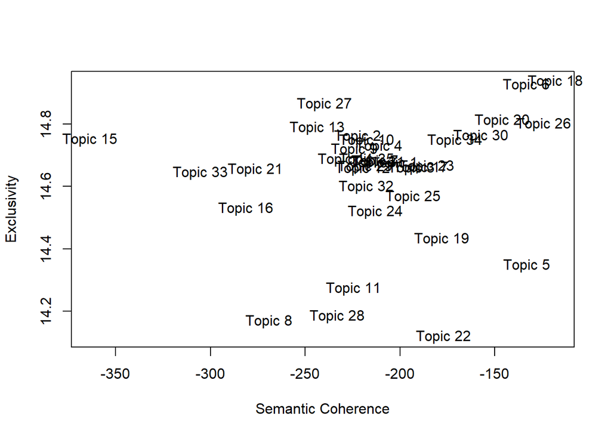

```r
## Topic quality: plot semantic coherence and exclusivity
topicQuality(model = stm_model,
             documents = stmdfm$documents,
             xlab = "Semantic Coherence",
             ylab = "Exclusivity",
             labels = 1:ncol(stm_model$theta),
             M = 15)
```

```r
# Check top words of outliers
labelTopics(stm_model,
            topics = c(8,15,22,28))
```

```
## Topic 8 Top Words:
##       Highest Prob: film, show, twitter, also, star, told, music
##       FREX: film, hollywood, actress, actor, song, nussbaum, wars
##       Lift: nussbaum, @dznussbaum, album, follow_daniel, rapper, wars, photo_posted
##       Score: wars, film, actress, nussbaum, @dznussbaum, follow_daniel, @jeromeehudson
## Topic 15 Top Words:
##       Highest Prob: email, author, said, twitter, huston, also, @warnerthuston
##       FREX: huston, @warnerthuston, follow_warner_todd, bathroom, author, giant, store
##       Lift: @warnerthuston, follow_warner_todd, giant, huston, charlotte, bathroom, bathrooms
##       Score: giant, duterte, @warnerthuston, follow_warner_todd, huston, bathroom, transgender
## Topic 22 Top Words:
##       Highest Prob: one, even, much, like, can, world, climate_change
##       FREX: climate_change, climate, science, scientists, global_warming, earth, professor
##       Lift: milk, global_warming, climate, climate_change, science, scientific, scientist
##       Score: milk, climate_change, climate, global_warming, scientists, science, scientific
## Topic 28 Top Words:
##       Highest Prob: clinton, fbi, investigation, information, emails, planned, said
##       FREX: emails, fbi, podesta, documents, clinton_foundation, state_department, clinton's
##       Lift: john_podesta, classified_information, ethical, podesta, parenthood's, schweizer, private_email_server
##       Score: clinton, emails, fbi, clinton's, parenthood, podesta, clinton_foundation
```

```r
# Check sample texts from topic 15
findThoughts(stm_model,
             texts = dfm_unsup@docvars$text,
             topics = 15,
             n = 5)
```

```
##
##  Topic 15:
##       A group of customers in Mississippi recently gathered in front of a Jackson Target to protest the retail giant’s pro-transgender bathroom policy.,As customers around the nation continue to react unfavorably to the decision by retail giant Target to allow men who claim to be transgender to u…
##      A group that ranks businesses by their respect for Christian buyers has identified the top ten alternatives to Target, as more Americans walk away from Target for embracing the radical gay lobby and the transgender movement.,The group ,Faith Driven Consumer,, which says it advocates for the …
##      A backlash is growing against retail giant Target Corp. after its announcement this week that it will allow men or women who claim to be transgender to use whichever bathroom or changing room they choose while shopping or working at their stores.,After two days of a social media firestorm, f…
##      Joining the woman who sued McDonald’s for serving coffee that was “too hot,” a trio of customers have decided to sue Chipotle for making the burritos “too full.”,The Mexican food outlet recently introduced a new burrito with a different meat choice and other fixings to bring down the total c…
##      A consumer protest by Americans has successfully forced Target Corp. to walk a few steps away from its disastrous $10 billion decision to back the radical transgender lobby.,Instead of opening all bathrooms and changing rooms to both sexes — for the benefit of a small number of transgender p…
```

- Face Validity

The topics appear to be distinct and well delineated, with a few exceptions that are somewhat ambiguous (Topic 24, 15).

- Predictive Validity

The monthly mean value of theta for each topic was plotted to show topic probabilities over time. Certain topics would naturally be expected to be more prevalent over certain time periods. Below is a list of such topics:

Topic 34 (Republican party primary candidates): expected to be more prevalent while primaries are ongoing Q1-2 2016; plots agree with this expectation.

Topic 20 (Democratic election candidates): expected to be more prevalent in the run up to the presidential election Q3-4 2016; plots agree with this expectation.

Topic 17 (Obama-Trump interaction / transition of power): expected to be more prevalent immediately following the presidential election Q4 2016: plots agree with this expectation.

Topic 14 (Supreme Court / Judiciary): expected to be more prevalent around the nomination of new candidates (Q1 2016; Q1 2017); plots agree with this expectation.

Topic 23 (Elections and polls): expected to be more prevalent around primary caucuses (Q1-2 2016) and presidential election (Q4 2016); plots agree with this expectation.

The above examples demonstrate that the model has good predictive validity.

- Semantic Validity

The correlation plot shows that there are topics that are related to each other which tend to co-occur in documents. For example, Topic 18 (gun control) is correlated with Topic 19 (deadly incidents/terrorist attacks/shootings) and Topic 14 (supreme court / judiciary). This makes sense as articles related to gun control would also likely reference challenges to the second amendment and deadly shooting incidents.

- Semantic Coherence & Topic Exclusivity

Topic 8 (Celebrities): topic still has good face validity and top FREX terms are coherent. Topic 22 (Climate Change): top probable terms have poor semantic coherence but FREX terms are coherent. Topic 28 (Hillary Clinton email controversy & investigation): topic does have poor semantic coherence on the face of it, but model has identified a salient topic even though it does require some domain/prior knowledge to identify.

Topic 15 (Warner Todd Huston articles / bathroom gender policy): this was identified as a possible junk topic from the outset. Review of some sample texts shows that documents are mostly about transgender bathroom policies. There is some overlap with Topic 13 (Gender & LGBT issues) and it may be better to disregard this topic for analysis.

5. What insights can be gleaned about right-wing media coverage of the 2016 US election? What election-related topics were derived from the model? What interesting temporal patterns exist? Why might the prevalence of certain important topics vary over 2016? Provide evidence in support of your answers.

Answer:

Right-wing media coverage of the 2016 US election focussed heavily on Republican party candidates during the primaries, with this topic (topic 34) having about 3% overall probability and as much as 10% during Q1 2016.

By contrast, democratic candidates (topic 20) had only about 2-3% probability during the same period rising to ~4.5% in Q3-4 in the run up to the election date. Analysis of texts show that the majority of this coverage was negative and may have been an attempt to discredit the candidates.

Supreme court judge appointment also featured (topic 14), with articles suggesting that appointment of SCOTUS nominee should wait until after the election as part of the presidential mandate.

The model identified a topic around Hillary Clinton’s email scandal and subsequent investigation (topic 28) and this was reported on most heavily on the run up to the election date (Q3-4 2016; ~4% probability), most likely as an attempt to disrupt her campaign.

Interestingly, Trump rallies (topic 2) featured very low on the overall topic frequency at ~1.5%.

Trump-Obama interaction / transition of power (topic 17), while having low overall topic frequency at ~2%, rose significantly in the period immediately after the election (Q4 2016) peaking at 5% probability.